# Midterm Data Translation Project

Jordan Gropper, Andrew Nalundasan

July 29, 2021

# 1 set up data, tidy data, and EDA

```r
library(ggannotate)    # annotation tool
library(gridExtra)     # use to put graphs together in the same frame
library(janitor)       # contains tidyverse functions for cross-tables
library(knitr)         # contains some table formatting functions
library(GGally)        # contains a custom correlation plot
library(scales)        # to get $ and , on axis in graph
library(tidyverse)     # contains ggplot2, dplyr, and several other packages
library(corrplot)      # used for correlation plot with good looks below
library(tidyr)         # tidy r
library(kableExtra)    # extra kable formatting
library(vtable)        # NHK special
library(gghighlight)   # visual formatting - highlights
library(agricolae)     # for statistical testing
library(huxtable)      # table formatting
library(jtools)        # export summs table
library(car)           # linear hypothesis
library(webshot)       # save a kable() table
```

# 2 Load and transform data

```r
# read data into environment and assign to variable
cereal_product <- read_csv("../02_raw_data/mtp_product_data.csv")
cereal_sales <- read_csv("../02_raw_data/mtp_sales_data.csv")
# create new column for 'company' for each cereal company
cereal_product <- cereal_product %>%
  mutate(company = case_when(
    str_starts(brand, 'GENERAL') ~ 'General Mills',
    str_starts(brand, 'KELLOGGS') ~ 'Kelloggs',
    str_starts(brand, 'POST') ~ 'Post'))

# remove cereal company name from 'brand' column
cereal_product <- cereal_product %>%
  mutate(brand = str_replace_all(brand, "GENERAL MILLS", "")) %>%
  mutate(brand = str_replace_all(brand, "KELLOGGS", "")) %>%
  mutate(brand = str_replace_all(brand, "POST", "")) %>%
  mutate(flavor = stringr::str_to_title(flavor)) %>%
  mutate(brand = str_to_title(brand)) %>%
  mutate(brand = str_replace_all(brand, "Cinnamon Tst Cr", "Cinnamon Toast Crunch"))

# update UPC formatting
cereal_product <- cereal_product %>%
  mutate(UPC = str_sub(UPC, 4, -1))

# update UPC formatting
cereal_product <- cereal_product %>%
  mutate(UPC = str_replace_all(UPC, "-", "."))

# join cereal_product and cereal_sales together
cereal_ps <- left_join(cereal_product, cereal_sales, by = "UPC")
```

# 3 Base EDA Step 1: Uni-variate non-graphical EDA

```r
# look at the data
head(cereal_ps, 10)
```

| UPC | brand | flavor | volume | package | company | iri_key | week | units | price | promo | ad |
| --- | --- | --- | --- | --- | --- | --- | --- | --- | --- | --- | --- |
| 01.16000.11653 | Cinnamon Toast Crunch | Cinnamon Toast | 0.06 | BOX | General Mills | 6.44e+05 | 6 | 5 | 0.5 | 0 | A |
| 01.16000.11653 | Cinnamon Toast Crunch | Cinnamon Toast | 0.06 | BOX | General Mills | 2.49e+05 | 5 | 2 | 0.5 | 0 | NONE |
| 01.16000.11653 | Cinnamon Toast Crunch | Cinnamon Toast | 0.06 | BOX | General Mills | 5.36e+05 | 11 | 3 | 0.5 | 0 | NONE |
| 01.16000.11653 | Cinnamon Toast Crunch | Cinnamon Toast | 0.06 | BOX | General Mills | 6.53e+05 | 13 | 10 | 0.5 | 0 | NONE |
| 01.16000.11653 | Cinnamon Toast Crunch | Cinnamon Toast | 0.06 | BOX | General Mills | 5.36e+05 | 16 | 10 | 0.5 | 0 | NONE |
| 01.16000.11945 | Cheerios | Toasted | 0.04 | BOX | General Mills | 6.76e+05 | 11 | 2 | 0.5 | 0 | NONE |
| 01.16000.11945 | Cheerios | Toasted | 0.04 | BOX | General Mills | 2.05e+05 | 13 | 8 | 0.5 | 0 | NONE |
| 01.16000.11945 | Cheerios | Toasted | 0.04 | BOX | General Mills | 2.49e+05 | 14 | 5 | 0.5 | 0 | NONE |
| 01.16000.11945 | Cheerios | Toasted | 0.04 | BOX | General Mills | 2.53e+05 | 2 | 14 | 0.5 | 0 | NONE |
| 01.16000.11945 | Cheerios | Toasted | 0.04 | BOX | General Mills | 6.45e+05 | 3 | 4 | 0.5 | 0 | NONE |

```r
str(cereal_ps)
```

```
## spec_tbl_df [21,850 x 12] (S3: spec_tbl_df/tbl_df/tbl/data.frame)
##  $ UPC    : chr [1:21850] "01.16000.11653" "01.16000.11653" "01.16000.11653" "01.16000.11653" ...
##  $ brand  : chr [1:21850] " Cinnamon Toast Crunch" " Cinnamon Toast Crunch" " Cinnamon Toast Crunch" " Cinnamon Toast Crunch" ...
##  $ flavor : chr [1:21850] "Cinnamon Toast" "Cinnamon Toast" "Cinnamon Toast" "Cinnamon Toast" ...
##  $ volume : num [1:21850] 0.06 0.06 0.06 0.06 0.06 0.04 0.04 0.04 0.04 0.04 ...
##  $ package: chr [1:21850] "BOX" "BOX" "BOX" "BOX" ...
##  $ company: chr [1:21850] "General Mills" "General Mills" "General Mills" "General Mills" ...
##  $ iri_key: num [1:21850] 644347 248741 535806 652727 535806 ...
##  $ week   : num [1:21850] 6 5 11 13 16 11 13 14 2 3 ...
##  $ units  : num [1:21850] 5 2 3 10 10 2 8 5 14 4 ...
##  $ price  : num [1:21850] 0.5 0.5 0.5 0.5 0.5 0.5 0.5 0.5 0.5 0.5 ...
##  $ promo  : num [1:21850] 0 0 0 0 0 0 0 0 0 0 ...
##  $ ad     : chr [1:21850] "A" "NONE" "NONE" "NONE" ...
##  - attr(*, "spec")=
##   .. cols(
##   ..   UPC = col_character(),
##   ..   brand = col_character(),
##   ..   flavor = col_character(),
##   ..   volume = col_double(),
##   ..   package = col_character()
##   .. )
```

```r
vtable(cereal_ps)
```

cereal_ps

| Name | Class | Values |
| --- | --- | --- |
| UPC | character |  |
| brand | character |  |
| flavor | character |  |
| volume | numeric | Num: 0.04 to 4 |
| package | character |  |
| company | character |  |
| iri_key | numeric | Num: 200171 to 8057418 |
| week | numeric | Num: 1 to 52 |
| units | numeric | Num: 1 to 28 |
| price | numeric | Num: 0.25 to 9.99 |
| promo | numeric | Num: 0 to 1 |
| ad | character |  |

```r
summary(cereal_ps)
```

```
##      UPC               brand              flavor              volume
##  Length:21850       Length:21850       Length:21850       Min.   :0.040
##  Class :character   Class :character   Class :character   1st Qu.:0.750
##  Mode  :character   Mode  :character   Mode  :character   Median :1.060
##                                                           Mean   :1.016
##                                                           3rd Qu.:1.120
##                                                           Max.   :4.000
##    package            company             iri_key             week
##  Length:21850       Length:21850       Min.   : 200171   Min.   : 1.00
##  Class :character   Class :character   1st Qu.: 241553   1st Qu.:14.00
##  Mode  :character   Mode  :character   Median : 273720   Median :27.00
##                                        Mean   : 454405   Mean   :26.62
##                                        3rd Qu.: 648547   3rd Qu.:40.00
##                                        Max.   :8057418   Max.   :52.00
##      units            price           promo            ad
##  Min.   : 1.000   Min.   :0.250   Min.   :0.000   Length:21850
##  1st Qu.: 3.000   1st Qu.:3.190   1st Qu.:0.000   Class :character
##  Median : 7.000   Median :3.790   Median :0.000   Mode  :character
##  Mean   : 8.579   Mean   :3.763   Mean   :0.208
##  3rd Qu.:12.000   3rd Qu.:4.390   3rd Qu.:0.000
##  Max.   :28.000   Max.   :9.990   Max.   :1.000
```

**Comments**

- data appears to be tidy
  - data in each column is of the same variable type
  - no duplicate columns
  - each row is an observation for the sale of a unit of cereal
- 6 character variables
  1. UPC
  2. brand
  3. flavor
  4. package
  5. company
  6. ad
- 5 numeric variables
  1. iri_key: identifier
  2. week: 1 to 52 for each week of the year - categorical
  3. units: 1-28
  4. price
  5. promo - binary yes/no
- Summary stats on Quantitative
  - volume: looks evenly distributed
  - units: appear to be right-skewed because mean >> median
    - median more representative than mean
  - price: appears to be right-skewed because Max >> 1st quartile, Median, and 3rd quartile
- Summary stats of Categorical
  - number obs == 21850

**Questions**

- Does producer name or brand effect the following:
  - sales
  - promos
  - ads
  - pricing
- Which variable(s) drive price the most?

# 4 Base EDA Step 2: Uni-variate graphical EDA

- Here we will examine each variable individually
- Examine how many observations in each variable

## 4.1 Categorical/Factor variables:

- Store, unique product number, Flavor, Advertisement, Promo, week, company, Brand, and Package

```r
# create objects to visualize all categorical/factor variables

company <- ggplot(data = cereal_ps, mapping = aes(company))

brand <- ggplot(data = cereal_ps, mapping = aes(brand))

flavor <- ggplot(data = cereal_ps, mapping = aes(flavor))

packaging <- ggplot(data = cereal_ps, mapping = aes(package))

advert <- ggplot(data = cereal_ps, mapping = aes(ad))

store <- ggplot(data = cereal_ps, mapping = aes(iri_key))

UPC <- ggplot(data = cereal_ps, mapping = aes(UPC))

promo <- ggplot(data = cereal_ps, mapping = aes(promo))

week_sold <- ggplot(data = cereal_ps, mapping = aes(week))
```

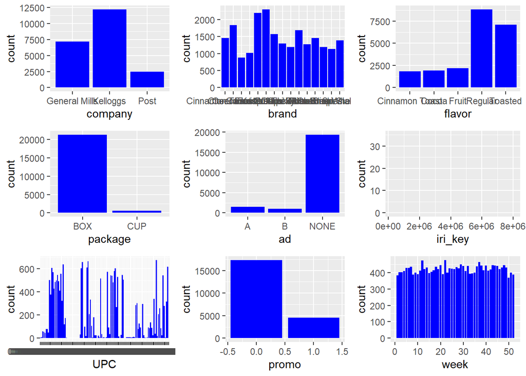

```r
# visualize all categorical/factor variables
grid.arrange(
company + geom_bar(fill = "blue"),
brand + geom_bar(fill = "blue"),
flavor + geom_bar(fill = "blue"),
packaging + geom_bar(fill = "blue"),
advert + geom_bar(fill = "blue"),
store + geom_bar(fill = "blue"),
UPC + geom_bar(fill = "blue"),
promo + geom_bar(fill = "blue"),
week_sold + geom_bar(fill = "blue"),
ncol = 3)
```

**Comments**

```
- Kelloggs has the highest amount of sales
- Can't read brand. Running this in chunk below
    - Frosted Flakes, Froot Loops, Cinammon Toast Crunch are top 3 sellers
- Regular and Toasted flavors are the highest sellers
- Boxed cereal dominates the market. Barely anyone purchases cereal in a cup
- A and B ads are similiar in count. ad == NONE dominates the market
- can't interpret iri_key
- Cereal sells more when there's no promo compared to when there is a promo
- A few spikes in sales depending on week, but mostly similar. No huge anomalies
```

**Questions**

- What are the gaps in UPC?
- What is iri_key?
  - Store Number
- What company makes the top 3 sellers?
- Why the striking difference in popularity between companies?
  - Because Kelloggs makes the most cereals?
  - Because Kelloggs covers the most flavor profiles?
  - Which company targets both adults and children?
    - Assumption that kids don’t like “Regular” flavor
    - Is “Regular” flavor a blanket statement?

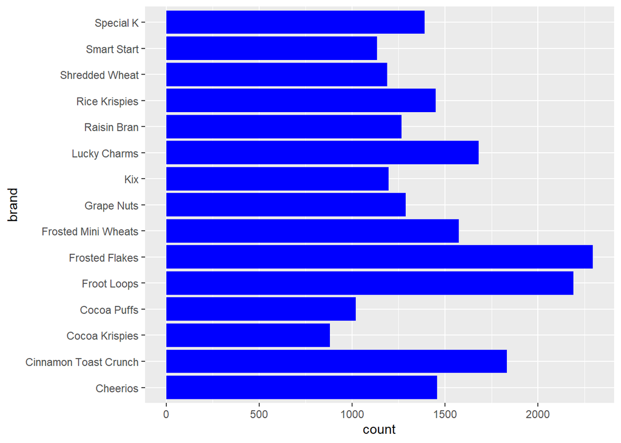

```r
brand + geom_bar(fill = "blue") + coord_flip()
```

## 4.2 Quantitative variables

1. Units
2. Price
3. Volume

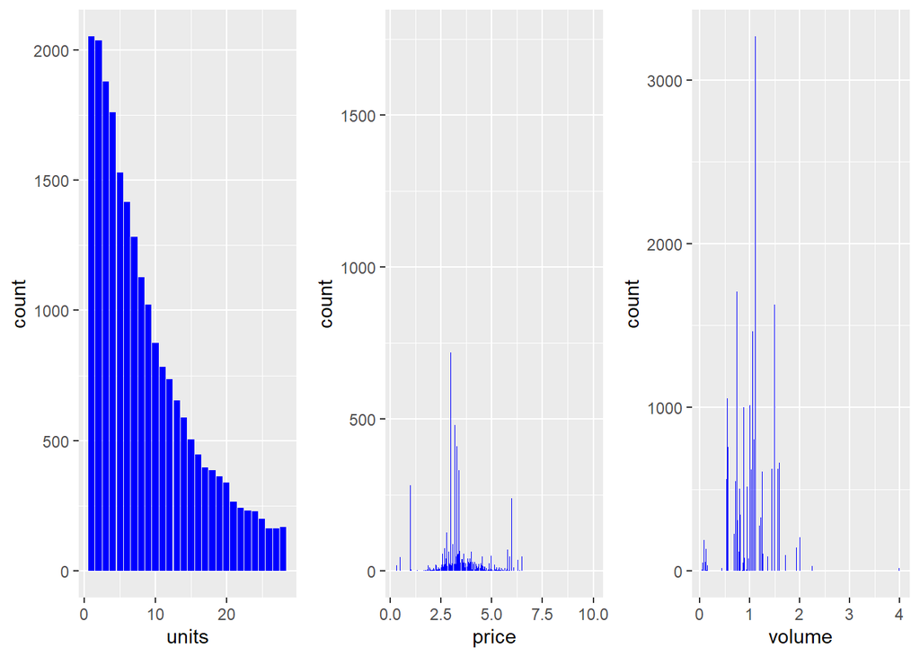

```r
# create objects for all quantitative variables
units <- ggplot(data = cereal_ps, mapping = aes(units))
price <- ggplot(data = cereal_ps, mapping = aes(price))
volume <- ggplot(data = cereal_ps, mapping = aes(volume))

# visualize all quantitative variables
grid.arrange(
units + geom_bar(fill = "blue"),
price + geom_bar(fill = "blue"),
volume + geom_bar(fill = "blue"),
ncol = 3)
```

**Comments**

[output not shown]

**Questions**

- Who buys cereal at $9.99? This is an outlier.
- Which cereal(s) are sold at the sweet spot of ~$3.75?
- Is it worth it for companies to even bother with different volume packages?

# 5 Base EDA Step 3: Multi-variate non-graphical

## 5.1 Categorical

### 5.1.1 Promotion and Advertisement

```r
# standard counts
cereal_ps %>%
  tabyl(promo, ad) %>% # creates table of counts
  adorn_totals(where = c("row", "col")) %>%
  kable() %>%
  kable_styling(bootstrap_options = "striped")
```

| promo | A | B | NONE | Total |
| --- | --- | --- | --- | --- |
| 0 | 683 | 402 | 16220 | 17305 |
| 1 | 773 | 659 | 3113 | 4545 |
| Total | 1456 | 1061 | 19333 | 21850 |

```r
# Proportion contingency/cross table
cereal_ps %>%
  tabyl(promo, ad) %>% # creates table of counts
  adorn_totals(where = c("row", "col")) %>%  # Total margins
  adorn_percentages(denominator = "all") %>% # creates proportions
  adorn_rounding(2) %>%  # round decimals
  kable() %>%
  kable_styling(bootstrap_options = "striped")
```

| promo | A | B | NONE | Total |
| --- | --- | --- | --- | --- |
| 0 | 0.03 | 0.02 | 0.74 | 0.79 |
| 1 | 0.04 | 0.03 | 0.14 | 0.21 |
| Total | 0.07 | 0.05 | 0.88 | 1.00 |

**Comments**

```
- no advertisements dominate the market
- rates of promotion are similar for advertisements A and B
    - advertisement A has 1% more promos than advertisement B
    - there are 2% more advertisements for A than there are for B
- when a cereal has no promos and no ads, this makes up 74% of cereal sales
- when a cereal is promoted and there are no advertisements of it, this makes 14% of cereal sales
```

**Questions**

- Do promotions have an effect on sales?
- Do advertisements have an effect on sales?
- Why does no promo and no advertisement yield the most sales?
  - this combo makes up 74% of cereal sales
- Why does a promo and no advertisement yield the second most sales?
  - this combo makes up 14% of cereal sales

### 5.1.2 Package and Flavor

```r
# standard counts
cereal_ps %>%
  tabyl(package, flavor) %>% # creates table of counts
  adorn_totals(where = c("row", "col")) %>%
  kable() %>%
  kable_styling(bootstrap_options = "striped")
```

| package | Cinnamon Toast | Cocoa | Fruit | Regular | Toasted | Total |
| --- | --- | --- | --- | --- | --- | --- |
| BOX | 1774 | 1897 | 2099 | 8644 | 6892 | 21306 |
| CUP | 60 | 4 | 93 | 172 | 215 | 544 |
| Total | 1834 | 1901 | 2192 | 8816 | 7107 | 21850 |

```r
# Proportion contingency/cross table
cereal_ps %>%
  tabyl(package, flavor) %>% # creates table of counts
  adorn_totals(where = c("row", "col")) %>%  # Total margins
  adorn_percentages(denominator = "all") %>% # creates proportions
  adorn_rounding(2) %>%  # round decimals
  kable() %>%
  kable_styling(bootstrap_options = "striped")
```

| package | Cinnamon Toast | Cocoa | Fruit | Regular | Toasted | Total |
| --- | --- | --- | --- | --- | --- | --- |
| BOX | 0.08 | 0.09 | 0.1 | 0.40 | 0.32 | 0.98 |
| CUP | 0.00 | 0.00 | 0.0 | 0.01 | 0.01 | 0.02 |
| Total | 0.08 | 0.09 | 0.1 | 0.40 | 0.33 | 1.00 |

**Comments**

```
- Regular flavor in a box has the most sales (40%)
- Toasted flavor in a box has the second most sales (32%)
- cereal from a cup barely sells at all (2% of the market)
```

**Questions**

- Why do companies even sell cups of cereal?
- Do promos and ads have any effect on Regular and Toasted sales?

### 5.1.3 Company and UPC

```r
# standard counts
comp_upc_count <- cereal_ps %>%
  tabyl(UPC, company) %>% # creates table of counts
  adorn_totals(where = c("row", "col"))

head(comp_upc_count, 10)
```

| UPC | General Mills | Kelloggs | Post | Total |
| --- | --- | --- | --- | --- |
| 01.16000.11653 | 5 | 0 | 0 | 5 |
| 01.16000.11945 | 8 | 0 | 0 | 8 |
| 01.16000.14154 | 60 | 0 | 0 | 60 |
| 01.16000.14156 | 57 | 0 | 0 | 57 |
| 01.16000.14159 | 47 | 0 | 0 | 47 |
| 01.16000.16179 | 81 | 0 | 0 | 81 |
| 01.16000.16181 | 78 | 0 | 0 | 78 |
| 01.16000.16182 | 50 | 0 | 0 | 50 |
| 01.16000.27507 | 504 | 0 | 0 | 504 |
| 01.16000.27509 | 378 | 0 | 0 | 378 |

```r
# Proportion contingency/cross table
comp_upc_prop <- cereal_ps %>%
  tabyl(UPC, company) %>% # creates table of counts
  adorn_totals(where = c("row", "col")) %>%  # Total margins
  adorn_percentages(denominator = "all") %>% # creates proportions
  adorn_rounding(2)  # round decimals

head(comp_upc_prop, 10)
```

| UPC | General Mills | Kelloggs | Post | Total |
| --- | --- | --- | --- | --- |
| 01.16000.11653 | 0 | 0 | 0 | 0 |
| 01.16000.11945 | 0 | 0 | 0 | 0 |
| 01.16000.14154 | 0 | 0 | 0 | 0 |
| 01.16000.14156 | 0 | 0 | 0 | 0 |
| 01.16000.14159 | 0 | 0 | 0 | 0 |
| 01.16000.16179 | 0 | 0 | 0 | 0 |
| 01.16000.16181 | 0 | 0 | 0 | 0 |
| 01.16000.16182 | 0 | 0 | 0 | 0 |
| 01.16000.27507 | 0.02 | 0 | 0 | 0.02 |
| 01.16000.27509 | 0.02 | 0 | 0 | 0.02 |

### 5.1.4 Company and Promo

```r
# standard counts
cereal_ps %>%
  tabyl(company, promo) %>% # creates table of counts
  adorn_totals(where = c("row", "col")) %>%
  kable() %>%
  kable_styling(bootstrap_options = "striped")
```

| company | 0 | 1 | Total |
| --- | --- | --- | --- |
| General Mills | 5909 | 1280 | 7189 |
| Kelloggs | 9470 | 2713 | 12183 |
| Post | 1926 | 552 | 2478 |
| Total | 17305 | 4545 | 21850 |

```r
# Proportion contingency/cross table
cereal_ps %>%
  tabyl(company, promo) %>% # creates table of counts
  adorn_totals(where = c("row", "col")) %>%  # Total margins
  adorn_percentages(denominator = "all") %>% # creates proportions
  adorn_rounding(2) %>%  # round decimals
  kable() %>%
  kable_styling(bootstrap_options = "striped")
```

| company | 0 | 1 | Total |
| --- | --- | --- | --- |
| General Mills | 0.27 | 0.06 | 0.33 |
| Kelloggs | 0.43 | 0.12 | 0.56 |
| Post | 0.09 | 0.03 | 0.11 |
| Total | 0.79 | 0.21 | 1.00 |

**Comments**

```
- Kelloggs sells the most with no promo
- Kelloggs sells double the amount of GM with promo
```

- Practical Significance:
  - Sales appear to drop significantly when a promo is in effect, but this might be due to the way the data is collected and the fact that we do not have all sales data for each day.
  - Is this consistent behavior?
  - Ho: Promotions do not effect sales.

**Questions**

- Why does Kelloggs sell the most without a promo
- Why do sales decrease for all companies when there is a promo?

### 5.1.5 Company and Advertisement

```r
# standard counts
co_ads_count <- cereal_ps %>%
  tabyl(company, ad) %>% # creates table of counts
  adorn_totals(where = c("row", "col")) %>%
  kable() %>%
  kable_styling(bootstrap_options = "striped")

co_ads_count
```

| company | A | B | NONE | Total |
| --- | --- | --- | --- | --- |
| General Mills | 442 | 272 | 6475 | 7189 |
| Kelloggs | 903 | 664 | 10616 | 12183 |
| Post | 111 | 125 | 2242 | 2478 |
| Total | 1456 | 1061 | 19333 | 21850 |

```r
# Proportion contingency/cross table
co_ads_prop <- cereal_ps %>%
  tabyl(company, ad) %>% # creates table of counts
  adorn_totals(where = c("row", "col")) %>%  # Total margins
  adorn_percentages(denominator = "all") %>% # creates proportions
  adorn_rounding(2) %>%  # round decimals
  kable() %>%
  kable_styling(bootstrap_options = "striped")

co_ads_prop
```

| company | A | B | NONE | Total |
| --- | --- | --- | --- | --- |
| General Mills | 0.02 | 0.01 | 0.30 | 0.33 |
| Kelloggs | 0.04 | 0.03 | 0.49 | 0.56 |
| Post | 0.01 | 0.01 | 0.10 | 0.11 |
| Total | 0.07 | 0.05 | 0.88 | 1.00 |

**Comments**

```
- Kelloggs sales appear to be double of GM while using Small Advertisements
- Kelloggs sales appear to be triple of GM while using Medium Adevertisements
- Kelloggs sales appear to be 19% higher than GM when using no ads
- All companies experience higher sales with no ads in effect
- Small ads appear to be more effective than Medium ads
    - size of ads do not effect sales for Post
```

- Practical Significance:
  - Sales appear to be boosted when no ads are in effect
  - Is this consistent behavior?
  - Ho: Ads have no effect on cereal sales.
  - Ho: Small ads do not drive higher sales than medium ads.

**Questions**

- Why are sales higher for all companies when no ads are in effect?

### 5.1.6 Package and Company

```r
# standard counts
cereal_ps %>%
  tabyl(company, package) %>% # creates table of counts
  adorn_totals(where = c("row", "col")) %>%
  kable() %>%
  kable_styling(bootstrap_options = "striped")
```

| company | BOX | CUP | Total |
| --- | --- | --- | --- |
| General Mills | 7025 | 164 | 7189 |
| Kelloggs | 11803 | 380 | 12183 |
| Post | 2478 | 0 | 2478 |
| Total | 21306 | 544 | 21850 |

```r
# Proportion contingency/cross table
cereal_ps %>%
  tabyl(company, package) %>% # creates table of counts
  adorn_totals(where = c("row", "col")) %>%  # Total margins
  adorn_percentages(denominator = "all") %>% # creates proportions
  adorn_rounding(2) %>%   # round decimals
  kable() %>%
  kable_styling(bootstrap_options = "striped")
```

| company | BOX | CUP | Total |
| --- | --- | --- | --- |
| General Mills | 0.32 | 0.01 | 0.33 |
| Kelloggs | 0.54 | 0.02 | 0.56 |
| Post | 0.11 | 0.00 | 0.11 |
| Total | 0.98 | 0.02 | 1.00 |

**Comments**

```
- Box cereal dominates the market at 98%
```

**Questions**

### 5.1.7 Flavor and package

```r
# standard counts
cereal_ps %>%
  tabyl(flavor, package) %>% # creates table of counts
  adorn_totals(where = c("row", "col")) %>%
  kable() %>%
  kable_styling(bootstrap_options = "striped")
```

| flavor | BOX | CUP | Total |
| --- | --- | --- | --- |
| Cinnamon Toast | 1774 | 60 | 1834 |
| Cocoa | 1897 | 4 | 1901 |
| Fruit | 2099 | 93 | 2192 |
| Regular | 8644 | 172 | 8816 |
| Toasted | 6892 | 215 | 7107 |
| Total | 21306 | 544 | 21850 |

```r
# Proportion contingency/cross table
cereal_ps %>%
  tabyl(flavor, package) %>% # creates table of counts
  adorn_totals(where = c("row", "col")) %>%  # Total margins
  adorn_percentages(denominator = "all") %>% # creates proportions
  adorn_rounding(2) %>%   # round decimals
  kable() %>%
  kable_styling(bootstrap_options = "striped")
```

| flavor | BOX | CUP | Total |
| --- | --- | --- | --- |
| Cinnamon Toast | 0.08 | 0.00 | 0.08 |
| Cocoa | 0.09 | 0.00 | 0.09 |
| Fruit | 0.10 | 0.00 | 0.10 |
| Regular | 0.40 | 0.01 | 0.40 |
| Toasted | 0.32 | 0.01 | 0.33 |
| Total | 0.98 | 0.02 | 1.00 |

**Comments**

```
- Regular and Toasted boxed cereals appear to make up ~72% of sales
- Cup cereal appears to have no practical significance
```

**Questions**

- Is it worth it for companies to offer cereal in a cup?
  - Practically, it does not make sense.
    - 2% of cup sales are for Regular and Toasted only
    - 0% sales from all other flavors
  - Ho: Cup cereal has no effect on sales.

### 5.1.8 Flavor and promo

```r
# standard counts
cereal_ps %>%
  tabyl(flavor, promo) %>% # creates table of counts
  adorn_totals(where = c("row", "col")) %>%
  kable() %>%
  kable_styling(bootstrap_options = "striped")
```

| flavor | 0 | 1 | Total |
| --- | --- | --- | --- |
| Cinnamon Toast | 1537 | 297 | 1834 |
| Cocoa | 1416 | 485 | 1901 |
| Fruit | 1673 | 519 | 2192 |
| Regular | 7057 | 1759 | 8816 |
| Toasted | 5622 | 1485 | 7107 |
| Total | 17305 | 4545 | 21850 |

```r
# Proportion contingency/cross table
cereal_ps %>%
  tabyl(flavor, promo) %>% # creates table of counts
  adorn_totals(where = c("row", "col")) %>%  # Total margins
  adorn_percentages(denominator = "all") %>% # creates proportions
  adorn_rounding(2) %>%   # round decimals
  kable() %>%
  kable_styling(bootstrap_options = "striped")
```

| flavor | 0 | 1 | Total |
| --- | --- | --- | --- |
| Cinnamon Toast | 0.07 | 0.01 | 0.08 |
| Cocoa | 0.06 | 0.02 | 0.09 |
| Fruit | 0.08 | 0.02 | 0.10 |
| Regular | 0.32 | 0.08 | 0.40 |
| Toasted | 0.26 | 0.07 | 0.33 |
| Total | 0.79 | 0.21 | 1.00 |

**Comments**

```
- Cereal sales drop when a promo is in effect
```

**Questions**

- Why do sales drop when cereal is being promoted?

### 5.1.9 Flavor and ad

```r
# standard counts
cereal_ps %>%
  tabyl(flavor, ad) %>% # creates table of counts
  adorn_totals(where = c("row", "col")) %>%
  kable() %>%
  kable_styling(bootstrap_options = "striped")
```

| flavor | A | B | NONE | Total |
| --- | --- | --- | --- | --- |
| Cinnamon Toast | 114 | 51 | 1669 | 1834 |
| Cocoa | 128 | 91 | 1682 | 1901 |
| Fruit | 153 | 108 | 1931 | 2192 |
| Regular | 516 | 439 | 7861 | 8816 |
| Toasted | 545 | 372 | 6190 | 7107 |
| Total | 1456 | 1061 | 19333 | 21850 |

```r
# Proportion contingency/cross table
cereal_ps %>%
  tabyl(flavor, ad) %>% # creates table of counts
  adorn_totals(where = c("row", "col")) %>%  # Total margins
  adorn_percentages(denominator = "all") %>% # creates proportions
  adorn_rounding(2) %>%   # round decimals
  kable() %>%
  kable_styling(bootstrap_options = "striped")
```

| flavor | A | B | NONE | Total |
| --- | --- | --- | --- | --- |
| Cinnamon Toast | 0.01 | 0.00 | 0.08 | 0.08 |
| Cocoa | 0.01 | 0.00 | 0.08 | 0.09 |
| Fruit | 0.01 | 0.00 | 0.09 | 0.10 |
| Regular | 0.02 | 0.02 | 0.36 | 0.40 |
| Toasted | 0.02 | 0.02 | 0.28 | 0.33 |
| Total | 0.07 | 0.05 | 0.88 | 1.00 |

**Comments**

```
- no difference between small ads and medium ads for Regular and Toasted sales
- Regular appears to sell 8% more than Toasted when no ads are in effect
```

**Questions**

- Is it worth it to have ad campaigns at all?

### 5.1.10 Brand and ads

```r
# standard counts
cereal_ps %>%
  tabyl(brand, ad) %>% # creates table of counts
  adorn_totals(where = c("row", "col")) %>%
  kable() %>%
  kable_styling(bootstrap_options = "striped")
```

| brand | A | B | NONE | Total |
| --- | --- | --- | --- | --- |
| Cheerios | 79 | 44 | 1335 | 1458 |
| Cinnamon Toast Crunch | 114 | 51 | 1669 | 1834 |
| Cocoa Krispies | 52 | 37 | 792 | 881 |
| Cocoa Puffs | 76 | 54 | 890 | 1020 |
| Froot Loops | 153 | 108 | 1931 | 2192 |
| Frosted Flakes | 141 | 124 | 2030 | 2295 |
| Frosted Mini Wheats | 127 | 88 | 1359 | 1574 |
| Grape Nuts | 46 | 63 | 1180 | 1289 |
| Kix | 70 | 54 | 1072 | 1196 |
| Lucky Charms | 103 | 69 | 1509 | 1681 |
| Raisin Bran | 67 | 47 | 1152 | 1266 |
| Rice Krispies | 114 | 88 | 1248 | 1450 |
| Shredded Wheat | 65 | 62 | 1062 | 1189 |
| Smart Start | 124 | 90 | 920 | 1134 |
| Special K | 125 | 82 | 1184 | 1391 |
| Total | 1456 | 1061 | 19333 | 21850 |

```r
# Proportion contingency/cross table
cereal_ps %>%
  tabyl(brand, ad) %>% # creates table of counts
  adorn_totals(where = c("row", "col")) %>%  # Total margins
  adorn_percentages(denominator = "all") %>% # creates proportions
  adorn_rounding(2) %>%     # round decimals
  kable() %>%
  kable_styling(bootstrap_options = "striped")
```

| brand | A | B | NONE | Total |
| --- | --- | --- | --- | --- |
| Cheerios | 0.00 | 0.00 | 0.06 | 0.07 |
| Cinnamon Toast Crunch | 0.01 | 0.00 | 0.08 | 0.08 |
| Cocoa Krispies | 0.00 | 0.00 | 0.04 | 0.04 |
| Cocoa Puffs | 0.00 | 0.00 | 0.04 | 0.05 |
| Froot Loops | 0.01 | 0.00 | 0.09 | 0.10 |
| Frosted Flakes | 0.01 | 0.01 | 0.09 | 0.11 |
| Frosted Mini Wheats | 0.01 | 0.00 | 0.06 | 0.07 |
| Grape Nuts | 0.00 | 0.00 | 0.05 | 0.06 |
| Kix | 0.00 | 0.00 | 0.05 | 0.05 |
| Lucky Charms | 0.00 | 0.00 | 0.07 | 0.08 |
| Raisin Bran | 0.00 | 0.00 | 0.05 | 0.06 |
| Rice Krispies | 0.01 | 0.00 | 0.06 | 0.07 |
| Shredded Wheat | 0.00 | 0.00 | 0.05 | 0.05 |
| Smart Start | 0.01 | 0.00 | 0.04 | 0.05 |
| Special K | 0.01 | 0.00 | 0.05 | 0.06 |
| Total | 0.07 | 0.05 | 0.88 | 1.00 |

**Comments**

```
- no practical significance for small and medium ad campaigns for any brand
- more sales experienced with no ads in effect
```

**Questions**

- Why are more sales happening when there are no ads in effect?

### 5.1.11 Brand and promo

```r
# standard counts
cereal_ps %>%
  tabyl(brand, promo) %>% # creates table of counts
  adorn_totals(where = c("row", "col")) %>%
  kable() %>%
  kable_styling(bootstrap_options = "striped")
```

| brand | 0 | 1 | Total |
| --- | --- | --- | --- |
| Cheerios | 1240 | 218 | 1458 |
| Cinnamon Toast Crunch | 1537 | 297 | 1834 |
| Cocoa Krispies | 647 | 234 | 881 |
| Cocoa Puffs | 769 | 251 | 1020 |
| Froot Loops | 1673 | 519 | 2192 |
| Frosted Flakes | 1819 | 476 | 2295 |
| Frosted Mini Wheats | 1248 | 326 | 1574 |
| Grape Nuts | 1002 | 287 | 1289 |
| Kix | 997 | 199 | 1196 |
| Lucky Charms | 1366 | 315 | 1681 |
| Raisin Bran | 1060 | 206 | 1266 |
| Rice Krispies | 1162 | 288 | 1450 |
| Shredded Wheat | 924 | 265 | 1189 |
| Smart Start | 812 | 322 | 1134 |
| Special K | 1049 | 342 | 1391 |
| Total | 17305 | 4545 | 21850 |

```r
# Proportion contingency/cross table
cereal_ps %>%
  tabyl(brand, promo) %>% # creates table of counts
  adorn_totals(where = c("row", "col")) %>%  # Total margins
  adorn_percentages(denominator = "all") %>% # creates proportions
  adorn_rounding(2) %>%     # round decimals
  kable() %>%
  kable_styling(bootstrap_options = "striped")
```

| brand | 0 | 1 | Total |
| --- | --- | --- | --- |
| Cheerios | 0.06 | 0.01 | 0.07 |
| Cinnamon Toast Crunch | 0.07 | 0.01 | 0.08 |
| Cocoa Krispies | 0.03 | 0.01 | 0.04 |
| Cocoa Puffs | 0.04 | 0.01 | 0.05 |
| Froot Loops | 0.08 | 0.02 | 0.10 |
| Frosted Flakes | 0.08 | 0.02 | 0.11 |
| Frosted Mini Wheats | 0.06 | 0.01 | 0.07 |
| Grape Nuts | 0.05 | 0.01 | 0.06 |
| Kix | 0.05 | 0.01 | 0.05 |
| Lucky Charms | 0.06 | 0.01 | 0.08 |
| Raisin Bran | 0.05 | 0.01 | 0.06 |
| Rice Krispies | 0.05 | 0.01 | 0.07 |
| Shredded Wheat | 0.04 | 0.01 | 0.05 |
| Smart Start | 0.04 | 0.01 | 0.05 |
| Special K | 0.05 | 0.02 | 0.06 |
| Total | 0.79 | 0.21 | 1.00 |

**Comments**

```
- Higher sales when brands are not being promoted (79%)
- Lower sales when brands are being promoted (21%)
```

**Questions**

- Why are more sales happening when there are no in-store promotions in effect?

### 5.1.12 Brand and Store

```r
#standard counts
store_brand_count  <- cereal_ps %>%
  tabyl(iri_key, brand) %>% # creates table of counts
  adorn_totals(where = c("row", "col"))

# Proportion contingency/cross table
store_brand_prop <- cereal_ps %>%
  tabyl(iri_key, brand) %>% # creates table of counts
  adorn_totals(where = c("row", "col")) %>%  # Total margins
  adorn_percentages(denominator = "all") %>% # creates proportions
  adorn_rounding(2)     # round decimals


head(store_brand_count, 10)
```

| iri_key | Cheerios | Cinnamon Toast Crunch | Cocoa Krispies | Cocoa Puffs | Froot Loops | Frosted Flakes | Frosted Mini Wheats | Grape Nuts | Kix | Lucky Charms | Raisin Bran | Rice Krispies | Shredded Wheat | Smart Start | Special K | Total |
| --- | --- | --- | --- | --- | --- | --- | --- | --- | --- | --- | --- | --- | --- | --- | --- | --- |
| 200171 | 1 | 2 | 2 | 1 | 1 | 1 | 0 | 1 | 0 | 0 | 1 | 2 | 0 | 1 | 2 | 15 |
| 200197 | 1 | 1 | 0 | 0 | 4 | 3 | 2 | 1 | 4 | 4 | 1 | 4 | 1 | 0 | 1 | 27 |
| 200272 | 2 | 0 | 0 | 0 | 3 | 2 | 0 | 4 | 1 | 0 | 1 | 2 | 0 | 2 | 0 | 17 |
| 200297 | 0 | 4 | 0 | 0 | 1 | 0 | 0 | 2 | 0 | 1 | 0 | 2 | 1 | 3 | 0 | 14 |
| 200341 | 0 | 1 | 1 | 1 | 1 | 3 | 2 | 1 | 4 | 0 | 0 | 1 | 1 | 1 | 1 | 18 |
| 200379 | 3 | 3 | 0 | 1 | 2 | 2 | 0 | 2 | 0 | 3 | 0 | 2 | 0 | 1 | 0 | 19 |
| 200391 | 0 | 1 | 2 | 0 | 1 | 3 | 1 | 1 | 1 | 2 | 1 | 1 | 2 | 1 | 1 | 18 |
| 200411 | 0 | 4 | 0 | 1 | 2 | 3 | 2 | 0 | 1 | 0 | 2 | 0 | 1 | 1 | 1 | 18 |
| 200439 | 2 | 1 | 1 | 0 | 2 | 0 | 1 | 0 | 1 | 0 | 1 | 3 | 0 | 0 | 0 | 12 |
| 200485 | 1 | 3 | 0 | 1 | 0 | 2 | 2 | 2 | 1 | 1 | 2 | 1 | 0 | 0 | 1 | 17 |

```r
head(store_brand_prop, 10)
```

| iri_key | Cheerios | Cinnamon Toast Crunch | Cocoa Krispies | Cocoa Puffs | Froot Loops | Frosted Flakes | Frosted Mini Wheats | Grape Nuts | Kix | Lucky Charms | Raisin Bran | Rice Krispies | Shredded Wheat | Smart Start | Special K | Total |
| --- | --- | --- | --- | --- | --- | --- | --- | --- | --- | --- | --- | --- | --- | --- | --- | --- |
| 200171 | 0 | 0 | 0 | 0 | 0 | 0 | 0 | 0 | 0 | 0 | 0 | 0 | 0 | 0 | 0 | 0 |
| 200197 | 0 | 0 | 0 | 0 | 0 | 0 | 0 | 0 | 0 | 0 | 0 | 0 | 0 | 0 | 0 | 0 |
| 200272 | 0 | 0 | 0 | 0 | 0 | 0 | 0 | 0 | 0 | 0 | 0 | 0 | 0 | 0 | 0 | 0 |
| 200297 | 0 | 0 | 0 | 0 | 0 | 0 | 0 | 0 | 0 | 0 | 0 | 0 | 0 | 0 | 0 | 0 |
| 200341 | 0 | 0 | 0 | 0 | 0 | 0 | 0 | 0 | 0 | 0 | 0 | 0 | 0 | 0 | 0 | 0 |
| 200379 | 0 | 0 | 0 | 0 | 0 | 0 | 0 | 0 | 0 | 0 | 0 | 0 | 0 | 0 | 0 | 0 |
| 200391 | 0 | 0 | 0 | 0 | 0 | 0 | 0 | 0 | 0 | 0 | 0 | 0 | 0 | 0 | 0 | 0 |
| 200411 | 0 | 0 | 0 | 0 | 0 | 0 | 0 | 0 | 0 | 0 | 0 | 0 | 0 | 0 | 0 | 0 |
| 200439 | 0 | 0 | 0 | 0 | 0 | 0 | 0 | 0 | 0 | 0 | 0 | 0 | 0 | 0 | 0 | 0 |
| 200485 | 0 | 0 | 0 | 0 | 0 | 0 | 0 | 0 | 0 | 0 | 0 | 0 | 0 | 0 | 0 | 0 |

### 5.1.13 Flavor and Brand

```r
# standard counts
cereal_ps %>%
  tabyl(flavor, brand) %>% # creates table of counts
  adorn_totals(where = c("row", "col")) %>%
  kable() %>%
  kable_styling(bootstrap_options = "striped")
```

| flavor | Cheerios | Cinnamon Toast Crunch | Cocoa Krispies | Cocoa Puffs | Froot Loops | Frosted Flakes | Frosted Mini Wheats | Grape Nuts | Kix | Lucky Charms | Raisin Bran | Rice Krispies | Shredded Wheat | Smart Start | Special K | Total |
| --- | --- | --- | --- | --- | --- | --- | --- | --- | --- | --- | --- | --- | --- | --- | --- | --- |
| Cinnamon Toast | 0 | 1834 | 0 | 0 | 0 | 0 | 0 | 0 | 0 | 0 | 0 | 0 | 0 | 0 | 0 | 1834 |
| Cocoa | 0 | 0 | 881 | 1020 | 0 | 0 | 0 | 0 | 0 | 0 | 0 | 0 | 0 | 0 | 0 | 1901 |
| Fruit | 0 | 0 | 0 | 0 | 2192 | 0 | 0 | 0 | 0 | 0 | 0 | 0 | 0 | 0 | 0 | 2192 |
| Regular | 4 | 0 | 0 | 0 | 0 | 2295 | 1574 | 1289 | 1196 | 3 | 1266 | 0 | 1189 | 0 | 0 | 8816 |
| Toasted | 1454 | 0 | 0 | 0 | 0 | 0 | 0 | 0 | 0 | 1678 | 0 | 1450 | 0 | 1134 | 1391 | 7107 |
| Total | 1458 | 1834 | 881 | 1020 | 2192 | 2295 | 1574 | 1289 | 1196 | 1681 | 1266 | 1450 | 1189 | 1134 | 1391 | 21850 |

```r
# Proportion contingency/cross table
cereal_ps %>%
  tabyl(flavor, brand) %>% # creates table of counts
  adorn_totals(where = c("row", "col")) %>%  # Total margins
  adorn_percentages(denominator = "all") %>% # creates proportions
  adorn_rounding(2) %>%      # round decimals
  kable() %>%
  kable_styling(bootstrap_options = "striped")
```

| flavor | Cheerios | Cinnamon Toast Crunch | Cocoa Krispies | Cocoa Puffs | Froot Loops | Frosted Flakes | Frosted Mini Wheats | Grape Nuts | Kix | Lucky Charms | Raisin Bran | Rice Krispies | Shredded Wheat | Smart Start | Special K | Total |
| --- | --- | --- | --- | --- | --- | --- | --- | --- | --- | --- | --- | --- | --- | --- | --- | --- |
| Cinnamon Toast | 0.00 | 0.08 | 0.00 | 0.00 | 0.0 | 0.00 | 0.00 | 0.00 | 0.00 | 0.00 | 0.00 | 0.00 | 0.00 | 0.00 | 0.00 | 0.08 |
| Cocoa | 0.00 | 0.00 | 0.04 | 0.05 | 0.0 | 0.00 | 0.00 | 0.00 | 0.00 | 0.00 | 0.00 | 0.00 | 0.00 | 0.00 | 0.00 | 0.09 |
| Fruit | 0.00 | 0.00 | 0.00 | 0.00 | 0.1 | 0.00 | 0.00 | 0.00 | 0.00 | 0.00 | 0.00 | 0.00 | 0.00 | 0.00 | 0.00 | 0.10 |
| Regular | 0.00 | 0.00 | 0.00 | 0.00 | 0.0 | 0.11 | 0.07 | 0.06 | 0.05 | 0.00 | 0.06 | 0.00 | 0.05 | 0.00 | 0.00 | 0.40 |
| Toasted | 0.07 | 0.00 | 0.00 | 0.00 | 0.0 | 0.00 | 0.00 | 0.00 | 0.00 | 0.08 | 0.00 | 0.07 | 0.00 | 0.05 | 0.06 | 0.33 |
| Total | 0.07 | 0.08 | 0.04 | 0.05 | 0.1 | 0.11 | 0.07 | 0.06 | 0.05 | 0.08 | 0.06 | 0.07 | 0.05 | 0.05 | 0.06 | 1.00 |

### 5.1.14 Company and Flavor

```r
# standard counts
cereal_ps %>%
  tabyl(company, flavor) %>% # creates table of counts
  adorn_totals(where = c("row", "col")) %>%
  kable() %>%
  kable_styling(bootstrap_options = "striped")
```

| company | Cinnamon Toast | Cocoa | Fruit | Regular | Toasted | Total |
| --- | --- | --- | --- | --- | --- | --- |
| General Mills | 1834 | 1020 | 0 | 1203 | 3132 | 7189 |
| Kelloggs | 0 | 881 | 2192 | 5135 | 3975 | 12183 |
| Post | 0 | 0 | 0 | 2478 | 0 | 2478 |
| Total | 1834 | 1901 | 2192 | 8816 | 7107 | 21850 |

```r
# Proportion contingency/cross table
cereal_ps %>%
  tabyl(company, flavor) %>% # creates table of counts
  adorn_totals(where = c("row", "col")) %>%  # Total margins
  adorn_percentages(denominator = "all") %>% # creates proportions
  adorn_rounding(2) %>%      # round decimals
  kable() %>%
  kable_styling(bootstrap_options = "striped")
```

| company | Cinnamon Toast | Cocoa | Fruit | Regular | Toasted | Total |
| --- | --- | --- | --- | --- | --- | --- |
| General Mills | 0.08 | 0.05 | 0.0 | 0.06 | 0.14 | 0.33 |
| Kelloggs | 0.00 | 0.04 | 0.1 | 0.24 | 0.18 | 0.56 |
| Post | 0.00 | 0.00 | 0.0 | 0.11 | 0.00 | 0.11 |
| Total | 0.08 | 0.09 | 0.1 | 0.40 | 0.33 | 1.00 |

**Comments**

```
- The market indicates appetite for Regular flavored cereal
    - How can GM compete with Kelloggs for Regular market share?
    - Even Post is beating GM on sales of Regular flavored cereal
```

**Questions**

- Could ads or promos drive Regular flavored GM cereals up to take market share from Kelloggs Regular flavored cereal?
- Perhaps focus should be on Cinnamon Toast to boost sales in this category where Kelloggs and Post can’t compete?

### 5.1.15 Week and Company

```r
# standard counts
cereal_ps %>%
  tabyl(week, company) %>% # creates table of counts
  adorn_totals(where = c("row", "col")) %>%
  kable() %>%
  kable_styling(bootstrap_options = "striped")
```

| week | General Mills | Kelloggs | Post | Total |
| --- | --- | --- | --- | --- |
| 1 | 134 | 219 | 30 | 383 |
| 2 | 142 | 221 | 38 | 401 |
| 3 | 141 | 208 | 53 | 402 |
| 4 | 137 | 218 | 54 | 409 |
| 5 | 162 | 221 | 44 | 427 |
| 6 | 145 | 231 | 52 | 428 |
| 7 | 136 | 250 | 49 | 435 |
| 8 | 124 | 207 | 55 | 386 |
| 9 | 152 | 185 | 61 | 398 |
| 10 | 148 | 197 | 44 | 389 |
| 11 | 142 | 213 | 57 | 412 |
| 12 | 171 | 245 | 57 | 473 |
| 13 | 143 | 237 | 41 | 421 |
| 14 | 144 | 243 | 42 | 429 |
| 15 | 137 | 219 | 41 | 397 |
| 16 | 127 | 227 | 49 | 403 |
| 17 | 146 | 213 | 55 | 414 |
| 18 | 159 | 223 | 53 | 435 |
| 19 | 130 | 243 | 48 | 421 |
| 20 | 131 | 260 | 54 | 445 |
| 21 | 130 | 208 | 51 | 389 |
| 22 | 154 | 260 | 61 | 475 |
| 23 | 135 | 201 | 63 | 399 |
| 24 | 160 | 216 | 49 | 425 |
| 25 | 125 | 246 | 52 | 423 |
| 26 | 126 | 249 | 45 | 420 |
| 27 | 144 | 230 | 58 | 432 |
| 28 | 137 | 233 | 54 | 424 |
| 29 | 141 | 257 | 51 | 449 |
| 30 | 145 | 233 | 61 | 439 |
| 31 | 116 | 243 | 50 | 409 |
| 32 | 142 | 258 | 39 | 439 |
| 33 | 120 | 238 | 35 | 393 |
| 34 | 100 | 248 | 46 | 394 |
| 35 | 129 | 231 | 39 | 399 |
| 36 | 127 | 269 | 40 | 436 |
| 37 | 134 | 283 | 47 | 464 |
| 38 | 148 | 251 | 42 | 441 |
| 39 | 124 | 250 | 40 | 414 |
| 40 | 135 | 254 | 52 | 441 |
| 41 | 122 | 242 | 48 | 412 |
| 42 | 151 | 242 | 25 | 418 |
| 43 | 156 | 242 | 47 | 445 |
| 44 | 155 | 242 | 44 | 441 |
| 45 | 139 | 253 | 47 | 439 |
| 46 | 147 | 220 | 53 | 420 |
| 47 | 126 | 261 | 44 | 431 |
| 48 | 150 | 251 | 44 | 445 |
| 49 | 125 | 256 | 48 | 429 |
| 50 | 127 | 197 | 45 | 369 |
| 51 | 124 | 225 | 51 | 400 |
| 52 | 144 | 214 | 30 | 388 |
| Total | 7189 | 12183 | 2478 | 21850 |

```r
# Proportion contingency/cross table
cereal_ps %>%
  tabyl(week, company) %>% # creates table of counts
  adorn_totals(where = c("row", "col")) %>%  # Total margins
  adorn_percentages(denominator = "all") %>% # creates proportions
  adorn_rounding(2) %>%      # round decimals
  kable() %>%
  kable_styling(bootstrap_options = "striped")
```

| week | General Mills | Kelloggs | Post | Total |
| --- | --- | --- | --- | --- |
| 1 | 0.01 | 0.01 | 0.00 | 0.02 |
| 2 | 0.01 | 0.01 | 0.00 | 0.02 |
| 3 | 0.01 | 0.01 | 0.00 | 0.02 |
| 4 | 0.01 | 0.01 | 0.00 | 0.02 |
| 5 | 0.01 | 0.01 | 0.00 | 0.02 |
| 6 | 0.01 | 0.01 | 0.00 | 0.02 |
| 7 | 0.01 | 0.01 | 0.00 | 0.02 |
| 8 | 0.01 | 0.01 | 0.00 | 0.02 |
| 9 | 0.01 | 0.01 | 0.00 | 0.02 |
| 10 | 0.01 | 0.01 | 0.00 | 0.02 |
| 11 | 0.01 | 0.01 | 0.00 | 0.02 |
| 12 | 0.01 | 0.01 | 0.00 | 0.02 |
| 13 | 0.01 | 0.01 | 0.00 | 0.02 |
| 14 | 0.01 | 0.01 | 0.00 | 0.02 |
| 15 | 0.01 | 0.01 | 0.00 | 0.02 |
| 16 | 0.01 | 0.01 | 0.00 | 0.02 |
| 17 | 0.01 | 0.01 | 0.00 | 0.02 |
| 18 | 0.01 | 0.01 | 0.00 | 0.02 |
| 19 | 0.01 | 0.01 | 0.00 | 0.02 |
| 20 | 0.01 | 0.01 | 0.00 | 0.02 |
| 21 | 0.01 | 0.01 | 0.00 | 0.02 |
| 22 | 0.01 | 0.01 | 0.00 | 0.02 |
| 23 | 0.01 | 0.01 | 0.00 | 0.02 |
| 24 | 0.01 | 0.01 | 0.00 | 0.02 |
| 25 | 0.01 | 0.01 | 0.00 | 0.02 |
| 26 | 0.01 | 0.01 | 0.00 | 0.02 |
| 27 | 0.01 | 0.01 | 0.00 | 0.02 |
| 28 | 0.01 | 0.01 | 0.00 | 0.02 |
| 29 | 0.01 | 0.01 | 0.00 | 0.02 |
| 30 | 0.01 | 0.01 | 0.00 | 0.02 |
| 31 | 0.01 | 0.01 | 0.00 | 0.02 |
| 32 | 0.01 | 0.01 | 0.00 | 0.02 |
| 33 | 0.01 | 0.01 | 0.00 | 0.02 |
| 34 | 0.00 | 0.01 | 0.00 | 0.02 |
| 35 | 0.01 | 0.01 | 0.00 | 0.02 |
| 36 | 0.01 | 0.01 | 0.00 | 0.02 |
| 37 | 0.01 | 0.01 | 0.00 | 0.02 |
| 38 | 0.01 | 0.01 | 0.00 | 0.02 |
| 39 | 0.01 | 0.01 | 0.00 | 0.02 |
| 40 | 0.01 | 0.01 | 0.00 | 0.02 |
| 41 | 0.01 | 0.01 | 0.00 | 0.02 |
| 42 | 0.01 | 0.01 | 0.00 | 0.02 |
| 43 | 0.01 | 0.01 | 0.00 | 0.02 |
| 44 | 0.01 | 0.01 | 0.00 | 0.02 |
| 45 | 0.01 | 0.01 | 0.00 | 0.02 |
| 46 | 0.01 | 0.01 | 0.00 | 0.02 |
| 47 | 0.01 | 0.01 | 0.00 | 0.02 |
| 48 | 0.01 | 0.01 | 0.00 | 0.02 |
| 49 | 0.01 | 0.01 | 0.00 | 0.02 |
| 50 | 0.01 | 0.01 | 0.00 | 0.02 |
| 51 | 0.01 | 0.01 | 0.00 | 0.02 |
| 52 | 0.01 | 0.01 | 0.00 | 0.02 |
| Total | 0.33 | 0.56 | 0.11 | 1.00 |

**Comments**

```
- No practical significance on higher selling weeks for any company
- Appears to be consistent sales for all companies year round
```

### 5.1.16 Week and Flavor

```r
# standard counts
cereal_ps %>%
  tabyl(week, flavor) %>% # creates table of counts
  adorn_totals(where = c("row", "col")) %>%
  kable() %>%
  kable_styling(bootstrap_options = "striped")
```

| week | Cinnamon Toast | Cocoa | Fruit | Regular | Toasted | Total |
| --- | --- | --- | --- | --- | --- | --- |
| 1 | 38 | 24 | 31 | 174 | 116 | 383 |
| 2 | 40 | 33 | 30 | 166 | 132 | 401 |
| 3 | 32 | 37 | 35 | 166 | 132 | 402 |
| 4 | 36 | 39 | 35 | 177 | 122 | 409 |
| 5 | 40 | 35 | 37 | 166 | 149 | 427 |
| 6 | 36 | 29 | 34 | 185 | 144 | 428 |
| 7 | 38 | 29 | 47 | 170 | 151 | 435 |
| 8 | 41 | 30 | 34 | 158 | 123 | 386 |
| 9 | 43 | 31 | 36 | 166 | 122 | 398 |
| 10 | 35 | 37 | 35 | 141 | 141 | 389 |
| 11 | 30 | 35 | 34 | 174 | 139 | 412 |
| 12 | 45 | 43 | 36 | 192 | 157 | 473 |
| 13 | 34 | 40 | 45 | 160 | 142 | 421 |
| 14 | 31 | 37 | 35 | 178 | 148 | 429 |
| 15 | 33 | 38 | 35 | 159 | 132 | 397 |
| 16 | 48 | 34 | 43 | 160 | 118 | 403 |
| 17 | 45 | 27 | 39 | 160 | 143 | 414 |
| 18 | 39 | 34 | 33 | 186 | 143 | 435 |
| 19 | 34 | 32 | 33 | 173 | 149 | 421 |
| 20 | 32 | 37 | 40 | 192 | 144 | 445 |
| 21 | 42 | 32 | 29 | 167 | 119 | 389 |
| 22 | 36 | 28 | 51 | 197 | 163 | 475 |
| 23 | 37 | 22 | 39 | 173 | 128 | 399 |
| 24 | 41 | 36 | 47 | 161 | 140 | 425 |
| 25 | 38 | 35 | 46 | 177 | 127 | 423 |
| 26 | 30 | 34 | 46 | 180 | 130 | 420 |
| 27 | 44 | 29 | 48 | 173 | 138 | 432 |
| 28 | 35 | 48 | 49 | 158 | 134 | 424 |
| 29 | 32 | 46 | 63 | 160 | 148 | 449 |
| 30 | 35 | 47 | 50 | 190 | 117 | 439 |
| 31 | 34 | 41 | 43 | 183 | 108 | 409 |
| 32 | 30 | 51 | 43 | 160 | 155 | 439 |
| 33 | 38 | 48 | 46 | 152 | 109 | 393 |
| 34 | 20 | 32 | 47 | 161 | 134 | 394 |
| 35 | 32 | 41 | 50 | 148 | 128 | 399 |
| 36 | 32 | 40 | 53 | 177 | 134 | 436 |
| 37 | 26 | 34 | 51 | 199 | 154 | 464 |
| 38 | 40 | 40 | 41 | 181 | 139 | 441 |
| 39 | 29 | 45 | 52 | 156 | 132 | 414 |
| 40 | 41 | 38 | 36 | 198 | 128 | 441 |
| 41 | 39 | 46 | 42 | 164 | 121 | 412 |
| 42 | 34 | 36 | 45 | 154 | 149 | 418 |
| 43 | 36 | 45 | 36 | 174 | 154 | 445 |
| 44 | 39 | 39 | 49 | 169 | 145 | 441 |
| 45 | 31 | 36 | 37 | 182 | 153 | 439 |
| 46 | 22 | 38 | 45 | 164 | 151 | 420 |
| 47 | 31 | 47 | 41 | 164 | 148 | 431 |
| 48 | 38 | 40 | 61 | 166 | 140 | 445 |
| 49 | 36 | 38 | 41 | 165 | 149 | 429 |
| 50 | 26 | 26 | 46 | 152 | 119 | 369 |
| 51 | 25 | 30 | 45 | 175 | 125 | 400 |
| 52 | 35 | 32 | 47 | 133 | 141 | 388 |
| Total | 1834 | 1901 | 2192 | 8816 | 7107 | 21850 |

```r
# Proportion contingency/cross table
cereal_ps %>%
  tabyl(week, flavor) %>% # creates table of counts
  adorn_totals(where = c("row", "col")) %>%  # Total margins
  adorn_percentages(denominator = "all") %>% # creates proportions
  adorn_rounding(2) %>%      # round decimals
  kable() %>%
  kable_styling(bootstrap_options = "striped")
```

| week | Cinnamon Toast | Cocoa | Fruit | Regular | Toasted | Total |
| --- | --- | --- | --- | --- | --- | --- |
| 1 | 0.00 | 0.00 | 0.0 | 0.01 | 0.01 | 0.02 |
| 2 | 0.00 | 0.00 | 0.0 | 0.01 | 0.01 | 0.02 |
| 3 | 0.00 | 0.00 | 0.0 | 0.01 | 0.01 | 0.02 |
| 4 | 0.00 | 0.00 | 0.0 | 0.01 | 0.01 | 0.02 |
| 5 | 0.00 | 0.00 | 0.0 | 0.01 | 0.01 | 0.02 |
| 6 | 0.00 | 0.00 | 0.0 | 0.01 | 0.01 | 0.02 |
| 7 | 0.00 | 0.00 | 0.0 | 0.01 | 0.01 | 0.02 |
| 8 | 0.00 | 0.00 | 0.0 | 0.01 | 0.01 | 0.02 |
| 9 | 0.00 | 0.00 | 0.0 | 0.01 | 0.01 | 0.02 |
| 10 | 0.00 | 0.00 | 0.0 | 0.01 | 0.01 | 0.02 |
| 11 | 0.00 | 0.00 | 0.0 | 0.01 | 0.01 | 0.02 |
| 12 | 0.00 | 0.00 | 0.0 | 0.01 | 0.01 | 0.02 |
| 13 | 0.00 | 0.00 | 0.0 | 0.01 | 0.01 | 0.02 |
| 14 | 0.00 | 0.00 | 0.0 | 0.01 | 0.01 | 0.02 |
| 15 | 0.00 | 0.00 | 0.0 | 0.01 | 0.01 | 0.02 |
| 16 | 0.00 | 0.00 | 0.0 | 0.01 | 0.01 | 0.02 |
| 17 | 0.00 | 0.00 | 0.0 | 0.01 | 0.01 | 0.02 |
| 18 | 0.00 | 0.00 | 0.0 | 0.01 | 0.01 | 0.02 |
| 19 | 0.00 | 0.00 | 0.0 | 0.01 | 0.01 | 0.02 |
| 20 | 0.00 | 0.00 | 0.0 | 0.01 | 0.01 | 0.02 |
| 21 | 0.00 | 0.00 | 0.0 | 0.01 | 0.01 | 0.02 |
| 22 | 0.00 | 0.00 | 0.0 | 0.01 | 0.01 | 0.02 |
| 23 | 0.00 | 0.00 | 0.0 | 0.01 | 0.01 | 0.02 |
| 24 | 0.00 | 0.00 | 0.0 | 0.01 | 0.01 | 0.02 |
| 25 | 0.00 | 0.00 | 0.0 | 0.01 | 0.01 | 0.02 |
| 26 | 0.00 | 0.00 | 0.0 | 0.01 | 0.01 | 0.02 |
| 27 | 0.00 | 0.00 | 0.0 | 0.01 | 0.01 | 0.02 |
| 28 | 0.00 | 0.00 | 0.0 | 0.01 | 0.01 | 0.02 |
| 29 | 0.00 | 0.00 | 0.0 | 0.01 | 0.01 | 0.02 |
| 30 | 0.00 | 0.00 | 0.0 | 0.01 | 0.01 | 0.02 |
| 31 | 0.00 | 0.00 | 0.0 | 0.01 | 0.00 | 0.02 |
| 32 | 0.00 | 0.00 | 0.0 | 0.01 | 0.01 | 0.02 |
| 33 | 0.00 | 0.00 | 0.0 | 0.01 | 0.00 | 0.02 |
| 34 | 0.00 | 0.00 | 0.0 | 0.01 | 0.01 | 0.02 |
| 35 | 0.00 | 0.00 | 0.0 | 0.01 | 0.01 | 0.02 |
| 36 | 0.00 | 0.00 | 0.0 | 0.01 | 0.01 | 0.02 |
| 37 | 0.00 | 0.00 | 0.0 | 0.01 | 0.01 | 0.02 |
| 38 | 0.00 | 0.00 | 0.0 | 0.01 | 0.01 | 0.02 |
| 39 | 0.00 | 0.00 | 0.0 | 0.01 | 0.01 | 0.02 |
| 40 | 0.00 | 0.00 | 0.0 | 0.01 | 0.01 | 0.02 |
| 41 | 0.00 | 0.00 | 0.0 | 0.01 | 0.01 | 0.02 |
| 42 | 0.00 | 0.00 | 0.0 | 0.01 | 0.01 | 0.02 |
| 43 | 0.00 | 0.00 | 0.0 | 0.01 | 0.01 | 0.02 |
| 44 | 0.00 | 0.00 | 0.0 | 0.01 | 0.01 | 0.02 |
| 45 | 0.00 | 0.00 | 0.0 | 0.01 | 0.01 | 0.02 |
| 46 | 0.00 | 0.00 | 0.0 | 0.01 | 0.01 | 0.02 |
| 47 | 0.00 | 0.00 | 0.0 | 0.01 | 0.01 | 0.02 |
| 48 | 0.00 | 0.00 | 0.0 | 0.01 | 0.01 | 0.02 |
| 49 | 0.00 | 0.00 | 0.0 | 0.01 | 0.01 | 0.02 |
| 50 | 0.00 | 0.00 | 0.0 | 0.01 | 0.01 | 0.02 |
| 51 | 0.00 | 0.00 | 0.0 | 0.01 | 0.01 | 0.02 |
| 52 | 0.00 | 0.00 | 0.0 | 0.01 | 0.01 | 0.02 |
| Total | 0.08 | 0.09 | 0.1 | 0.40 | 0.33 | 1.00 |

**Comments**

```
- No practical significance on higher selling weeks for any flavor
- Appears to be consistent sales for all flavors year round
```

### 5.1.17 Week and Brand

```r
#standard counts
cereal_ps %>%
  tabyl(week, brand) %>% # creates table of counts
  adorn_totals(where = c("row", "col")) %>%
  kable() %>%
  kable_styling(bootstrap_options = "striped")
```

| week | Cheerios | Cinnamon Toast Crunch | Cocoa Krispies | Cocoa Puffs | Froot Loops | Frosted Flakes | Frosted Mini Wheats | Grape Nuts | Kix | Lucky Charms | Raisin Bran | Rice Krispies | Shredded Wheat | Smart Start | Special K | Total |
| --- | --- | --- | --- | --- | --- | --- | --- | --- | --- | --- | --- | --- | --- | --- | --- | --- |
| 1 | 25 | 38 | 8 | 16 | 31 | 61 | 31 | 18 | 23 | 32 | 29 | 23 | 12 | 15 | 21 | 383 |
| 2 | 28 | 40 | 17 | 16 | 30 | 45 | 36 | 22 | 18 | 40 | 29 | 22 | 16 | 22 | 20 | 401 |
| 3 | 30 | 32 | 14 | 23 | 35 | 45 | 34 | 28 | 19 | 37 | 15 | 22 | 25 | 16 | 27 | 402 |
| 4 | 24 | 36 | 13 | 26 | 35 | 46 | 30 | 31 | 19 | 32 | 28 | 24 | 23 | 20 | 22 | 409 |
| 5 | 37 | 40 | 18 | 17 | 37 | 43 | 23 | 27 | 30 | 38 | 26 | 26 | 17 | 16 | 32 | 427 |
| 6 | 38 | 36 | 7 | 22 | 34 | 58 | 25 | 29 | 19 | 30 | 31 | 29 | 23 | 19 | 28 | 428 |
| 7 | 28 | 38 | 8 | 21 | 47 | 52 | 37 | 27 | 11 | 38 | 21 | 25 | 22 | 33 | 27 | 435 |
| 8 | 18 | 41 | 9 | 21 | 34 | 44 | 22 | 31 | 13 | 31 | 24 | 33 | 24 | 17 | 24 | 386 |
| 9 | 27 | 43 | 8 | 23 | 36 | 32 | 27 | 31 | 24 | 35 | 22 | 22 | 30 | 21 | 17 | 398 |
| 10 | 35 | 35 | 9 | 28 | 35 | 29 | 34 | 25 | 12 | 38 | 22 | 30 | 19 | 15 | 23 | 389 |
| 11 | 26 | 30 | 10 | 25 | 34 | 43 | 28 | 32 | 22 | 39 | 24 | 35 | 25 | 19 | 20 | 412 |
| 12 | 36 | 45 | 18 | 25 | 36 | 46 | 31 | 28 | 29 | 36 | 29 | 28 | 29 | 25 | 32 | 473 |
| 13 | 29 | 34 | 15 | 25 | 45 | 45 | 28 | 20 | 25 | 30 | 21 | 29 | 21 | 31 | 23 | 421 |
| 14 | 30 | 31 | 11 | 26 | 35 | 48 | 39 | 26 | 20 | 37 | 28 | 29 | 16 | 26 | 27 | 429 |
| 15 | 29 | 33 | 14 | 24 | 35 | 47 | 29 | 24 | 19 | 32 | 23 | 27 | 17 | 23 | 21 | 397 |
| 16 | 23 | 48 | 14 | 20 | 43 | 41 | 26 | 24 | 16 | 20 | 28 | 31 | 25 | 18 | 26 | 403 |
| 17 | 29 | 45 | 13 | 14 | 39 | 34 | 31 | 26 | 23 | 35 | 17 | 28 | 29 | 24 | 27 | 414 |
| 18 | 28 | 39 | 8 | 26 | 33 | 44 | 37 | 28 | 30 | 36 | 22 | 25 | 25 | 24 | 30 | 435 |
| 19 | 27 | 34 | 13 | 19 | 33 | 53 | 33 | 29 | 19 | 31 | 20 | 34 | 19 | 22 | 35 | 421 |
| 20 | 21 | 32 | 18 | 19 | 40 | 58 | 32 | 27 | 26 | 33 | 22 | 38 | 27 | 19 | 33 | 445 |
| 21 | 22 | 42 | 15 | 17 | 29 | 52 | 26 | 24 | 16 | 33 | 22 | 21 | 27 | 24 | 19 | 389 |
| 22 | 39 | 36 | 15 | 13 | 51 | 47 | 39 | 33 | 28 | 38 | 22 | 21 | 28 | 34 | 31 | 475 |
| 23 | 27 | 37 | 7 | 15 | 39 | 32 | 25 | 26 | 27 | 29 | 26 | 25 | 37 | 22 | 25 | 399 |
| 24 | 33 | 41 | 14 | 22 | 47 | 34 | 35 | 28 | 23 | 41 | 20 | 23 | 21 | 20 | 23 | 425 |
| 25 | 20 | 38 | 17 | 18 | 46 | 36 | 42 | 24 | 19 | 30 | 28 | 30 | 28 | 17 | 30 | 423 |
| 26 | 25 | 30 | 18 | 16 | 46 | 48 | 29 | 29 | 23 | 32 | 35 | 30 | 16 | 23 | 20 | 420 |
| 27 | 26 | 44 | 12 | 17 | 48 | 49 | 21 | 33 | 19 | 38 | 26 | 33 | 25 | 22 | 19 | 432 |
| 28 | 23 | 35 | 23 | 25 | 49 | 40 | 29 | 30 | 22 | 32 | 13 | 22 | 24 | 27 | 30 | 424 |
| 29 | 30 | 32 | 29 | 17 | 63 | 40 | 19 | 24 | 26 | 36 | 23 | 28 | 27 | 24 | 31 | 449 |
| 30 | 27 | 35 | 20 | 27 | 50 | 40 | 31 | 32 | 29 | 27 | 28 | 25 | 29 | 15 | 24 | 439 |
| 31 | 16 | 34 | 27 | 14 | 43 | 45 | 35 | 28 | 26 | 26 | 27 | 19 | 22 | 21 | 26 | 409 |
| 32 | 32 | 30 | 26 | 25 | 43 | 53 | 28 | 21 | 21 | 34 | 18 | 36 | 18 | 20 | 34 | 439 |
| 33 | 22 | 38 | 28 | 20 | 46 | 36 | 39 | 18 | 22 | 18 | 20 | 18 | 17 | 22 | 29 | 393 |
| 34 | 22 | 20 | 21 | 11 | 47 | 39 | 31 | 24 | 25 | 22 | 20 | 30 | 22 | 31 | 29 | 394 |
| 35 | 17 | 32 | 22 | 19 | 50 | 39 | 29 | 17 | 24 | 37 | 15 | 24 | 22 | 24 | 28 | 399 |
| 36 | 28 | 32 | 23 | 17 | 53 | 50 | 34 | 19 | 19 | 31 | 34 | 33 | 21 | 21 | 21 | 436 |
| 37 | 30 | 26 | 19 | 15 | 51 | 48 | 34 | 20 | 32 | 31 | 38 | 29 | 27 | 32 | 32 | 464 |
| 38 | 34 | 40 | 21 | 19 | 41 | 57 | 32 | 15 | 25 | 30 | 25 | 36 | 27 | 17 | 22 | 441 |
| 39 | 28 | 29 | 26 | 19 | 52 | 40 | 30 | 24 | 25 | 23 | 21 | 33 | 16 | 23 | 25 | 414 |
| 40 | 27 | 41 | 22 | 16 | 36 | 52 | 35 | 25 | 25 | 26 | 34 | 26 | 27 | 26 | 23 | 441 |
| 41 | 23 | 39 | 27 | 19 | 42 | 38 | 29 | 23 | 20 | 21 | 29 | 34 | 25 | 15 | 28 | 412 |
| 42 | 29 | 34 | 18 | 18 | 45 | 43 | 29 | 9 | 30 | 40 | 27 | 25 | 16 | 23 | 32 | 418 |
| 43 | 32 | 36 | 21 | 24 | 36 | 47 | 27 | 22 | 32 | 32 | 21 | 34 | 25 | 27 | 29 | 445 |
| 44 | 34 | 39 | 23 | 16 | 49 | 37 | 33 | 25 | 31 | 35 | 24 | 32 | 19 | 17 | 27 | 441 |
| 45 | 42 | 31 | 21 | 15 | 37 | 46 | 30 | 25 | 29 | 22 | 30 | 32 | 22 | 26 | 31 | 439 |
| 46 | 33 | 22 | 15 | 23 | 45 | 39 | 25 | 24 | 25 | 44 | 22 | 30 | 29 | 15 | 29 | 420 |
| 47 | 22 | 31 | 23 | 24 | 41 | 48 | 29 | 17 | 20 | 29 | 23 | 31 | 27 | 20 | 46 | 431 |
| 48 | 31 | 38 | 17 | 23 | 61 | 48 | 31 | 24 | 23 | 35 | 20 | 35 | 20 | 22 | 17 | 445 |
| 49 | 32 | 36 | 25 | 13 | 41 | 40 | 27 | 27 | 19 | 25 | 31 | 31 | 21 | 27 | 34 | 429 |
| 50 | 24 | 26 | 13 | 13 | 46 | 34 | 19 | 24 | 33 | 31 | 21 | 23 | 21 | 15 | 26 | 369 |
| 51 | 27 | 25 | 17 | 13 | 45 | 47 | 31 | 27 | 24 | 35 | 22 | 18 | 24 | 21 | 24 | 400 |
| 52 | 33 | 35 | 11 | 21 | 47 | 37 | 28 | 15 | 17 | 38 | 20 | 23 | 15 | 16 | 32 | 388 |
| Total | 1458 | 1834 | 881 | 1020 | 2192 | 2295 | 1574 | 1289 | 1196 | 1681 | 1266 | 1450 | 1189 | 1134 | 1391 | 21850 |

```r
# Proportion contingency/cross table
cereal_ps %>%
  tabyl(week, brand) %>% # creates table of counts
  adorn_totals(where = c("row", "col")) %>%  # Total margins
  adorn_percentages(denominator = "all") %>% # creates proportions
  adorn_rounding(2) %>%      # round decimals
  kable() %>%
  kable_styling(bootstrap_options = "striped")
```

| week | Cheerios | Cinnamon Toast Crunch | Cocoa Krispies | Cocoa Puffs | Froot Loops | Frosted Flakes | Frosted Mini Wheats | Grape Nuts | Kix | Lucky Charms | Raisin Bran | Rice Krispies | Shredded Wheat | Smart Start | Special K | Total |
| --- | --- | --- | --- | --- | --- | --- | --- | --- | --- | --- | --- | --- | --- | --- | --- | --- |
| 1 | 0.00 | 0.00 | 0.00 | 0.00 | 0.0 | 0.00 | 0.00 | 0.00 | 0.00 | 0.00 | 0.00 | 0.00 | 0.00 | 0.00 | 0.00 | 0.02 |
| 2 | 0.00 | 0.00 | 0.00 | 0.00 | 0.0 | 0.00 | 0.00 | 0.00 | 0.00 | 0.00 | 0.00 | 0.00 | 0.00 | 0.00 | 0.00 | 0.02 |
| 3 | 0.00 | 0.00 | 0.00 | 0.00 | 0.0 | 0.00 | 0.00 | 0.00 | 0.00 | 0.00 | 0.00 | 0.00 | 0.00 | 0.00 | 0.00 | 0.02 |
| 4 | 0.00 | 0.00 | 0.00 | 0.00 | 0.0 | 0.00 | 0.00 | 0.00 | 0.00 | 0.00 | 0.00 | 0.00 | 0.00 | 0.00 | 0.00 | 0.02 |
| 5 | 0.00 | 0.00 | 0.00 | 0.00 | 0.0 | 0.00 | 0.00 | 0.00 | 0.00 | 0.00 | 0.00 | 0.00 | 0.00 | 0.00 | 0.00 | 0.02 |
| 6 | 0.00 | 0.00 | 0.00 | 0.00 | 0.0 | 0.00 | 0.00 | 0.00 | 0.00 | 0.00 | 0.00 | 0.00 | 0.00 | 0.00 | 0.00 | 0.02 |
| 7 | 0.00 | 0.00 | 0.00 | 0.00 | 0.0 | 0.00 | 0.00 | 0.00 | 0.00 | 0.00 | 0.00 | 0.00 | 0.00 | 0.00 | 0.00 | 0.02 |
| 8 | 0.00 | 0.00 | 0.00 | 0.00 | 0.0 | 0.00 | 0.00 | 0.00 | 0.00 | 0.00 | 0.00 | 0.00 | 0.00 | 0.00 | 0.00 | 0.02 |
| 9 | 0.00 | 0.00 | 0.00 | 0.00 | 0.0 | 0.00 | 0.00 | 0.00 | 0.00 | 0.00 | 0.00 | 0.00 | 0.00 | 0.00 | 0.00 | 0.02 |
| 10 | 0.00 | 0.00 | 0.00 | 0.00 | 0.0 | 0.00 | 0.00 | 0.00 | 0.00 | 0.00 | 0.00 | 0.00 | 0.00 | 0.00 | 0.00 | 0.02 |
| 11 | 0.00 | 0.00 | 0.00 | 0.00 | 0.0 | 0.00 | 0.00 | 0.00 | 0.00 | 0.00 | 0.00 | 0.00 | 0.00 | 0.00 | 0.00 | 0.02 |
| 12 | 0.00 | 0.00 | 0.00 | 0.00 | 0.0 | 0.00 | 0.00 | 0.00 | 0.00 | 0.00 | 0.00 | 0.00 | 0.00 | 0.00 | 0.00 | 0.02 |
| 13 | 0.00 | 0.00 | 0.00 | 0.00 | 0.0 | 0.00 | 0.00 | 0.00 | 0.00 | 0.00 | 0.00 | 0.00 | 0.00 | 0.00 | 0.00 | 0.02 |
| 14 | 0.00 | 0.00 | 0.00 | 0.00 | 0.0 | 0.00 | 0.00 | 0.00 | 0.00 | 0.00 | 0.00 | 0.00 | 0.00 | 0.00 | 0.00 | 0.02 |
| 15 | 0.00 | 0.00 | 0.00 | 0.00 | 0.0 | 0.00 | 0.00 | 0.00 | 0.00 | 0.00 | 0.00 | 0.00 | 0.00 | 0.00 | 0.00 | 0.02 |
| 16 | 0.00 | 0.00 | 0.00 | 0.00 | 0.0 | 0.00 | 0.00 | 0.00 | 0.00 | 0.00 | 0.00 | 0.00 | 0.00 | 0.00 | 0.00 | 0.02 |
| 17 | 0.00 | 0.00 | 0.00 | 0.00 | 0.0 | 0.00 | 0.00 | 0.00 | 0.00 | 0.00 | 0.00 | 0.00 | 0.00 | 0.00 | 0.00 | 0.02 |
| 18 | 0.00 | 0.00 | 0.00 | 0.00 | 0.0 | 0.00 | 0.00 | 0.00 | 0.00 | 0.00 | 0.00 | 0.00 | 0.00 | 0.00 | 0.00 | 0.02 |
| 19 | 0.00 | 0.00 | 0.00 | 0.00 | 0.0 | 0.00 | 0.00 | 0.00 | 0.00 | 0.00 | 0.00 | 0.00 | 0.00 | 0.00 | 0.00 | 0.02 |
| 20 | 0.00 | 0.00 | 0.00 | 0.00 | 0.0 | 0.00 | 0.00 | 0.00 | 0.00 | 0.00 | 0.00 | 0.00 | 0.00 | 0.00 | 0.00 | 0.02 |
| 21 | 0.00 | 0.00 | 0.00 | 0.00 | 0.0 | 0.00 | 0.00 | 0.00 | 0.00 | 0.00 | 0.00 | 0.00 | 0.00 | 0.00 | 0.00 | 0.02 |
| 22 | 0.00 | 0.00 | 0.00 | 0.00 | 0.0 | 0.00 | 0.00 | 0.00 | 0.00 | 0.00 | 0.00 | 0.00 | 0.00 | 0.00 | 0.00 | 0.02 |
| 23 | 0.00 | 0.00 | 0.00 | 0.00 | 0.0 | 0.00 | 0.00 | 0.00 | 0.00 | 0.00 | 0.00 | 0.00 | 0.00 | 0.00 | 0.00 | 0.02 |
| 24 | 0.00 | 0.00 | 0.00 | 0.00 | 0.0 | 0.00 | 0.00 | 0.00 | 0.00 | 0.00 | 0.00 | 0.00 | 0.00 | 0.00 | 0.00 | 0.02 |
| 25 | 0.00 | 0.00 | 0.00 | 0.00 | 0.0 | 0.00 | 0.00 | 0.00 | 0.00 | 0.00 | 0.00 | 0.00 | 0.00 | 0.00 | 0.00 | 0.02 |
| 26 | 0.00 | 0.00 | 0.00 | 0.00 | 0.0 | 0.00 | 0.00 | 0.00 | 0.00 | 0.00 | 0.00 | 0.00 | 0.00 | 0.00 | 0.00 | 0.02 |
| 27 | 0.00 | 0.00 | 0.00 | 0.00 | 0.0 | 0.00 | 0.00 | 0.00 | 0.00 | 0.00 | 0.00 | 0.00 | 0.00 | 0.00 | 0.00 | 0.02 |
| 28 | 0.00 | 0.00 | 0.00 | 0.00 | 0.0 | 0.00 | 0.00 | 0.00 | 0.00 | 0.00 | 0.00 | 0.00 | 0.00 | 0.00 | 0.00 | 0.02 |
| 29 | 0.00 | 0.00 | 0.00 | 0.00 | 0.0 | 0.00 | 0.00 | 0.00 | 0.00 | 0.00 | 0.00 | 0.00 | 0.00 | 0.00 | 0.00 | 0.02 |
| 30 | 0.00 | 0.00 | 0.00 | 0.00 | 0.0 | 0.00 | 0.00 | 0.00 | 0.00 | 0.00 | 0.00 | 0.00 | 0.00 | 0.00 | 0.00 | 0.02 |
| 31 | 0.00 | 0.00 | 0.00 | 0.00 | 0.0 | 0.00 | 0.00 | 0.00 | 0.00 | 0.00 | 0.00 | 0.00 | 0.00 | 0.00 | 0.00 | 0.02 |
| 32 | 0.00 | 0.00 | 0.00 | 0.00 | 0.0 | 0.00 | 0.00 | 0.00 | 0.00 | 0.00 | 0.00 | 0.00 | 0.00 | 0.00 | 0.00 | 0.02 |
| 33 | 0.00 | 0.00 | 0.00 | 0.00 | 0.0 | 0.00 | 0.00 | 0.00 | 0.00 | 0.00 | 0.00 | 0.00 | 0.00 | 0.00 | 0.00 | 0.02 |
| 34 | 0.00 | 0.00 | 0.00 | 0.00 | 0.0 | 0.00 | 0.00 | 0.00 | 0.00 | 0.00 | 0.00 | 0.00 | 0.00 | 0.00 | 0.00 | 0.02 |
| 35 | 0.00 | 0.00 | 0.00 | 0.00 | 0.0 | 0.00 | 0.00 | 0.00 | 0.00 | 0.00 | 0.00 | 0.00 | 0.00 | 0.00 | 0.00 | 0.02 |
| 36 | 0.00 | 0.00 | 0.00 | 0.00 | 0.0 | 0.00 | 0.00 | 0.00 | 0.00 | 0.00 | 0.00 | 0.00 | 0.00 | 0.00 | 0.00 | 0.02 |
| 37 | 0.00 | 0.00 | 0.00 | 0.00 | 0.0 | 0.00 | 0.00 | 0.00 | 0.00 | 0.00 | 0.00 | 0.00 | 0.00 | 0.00 | 0.00 | 0.02 |
| 38 | 0.00 | 0.00 | 0.00 | 0.00 | 0.0 | 0.00 | 0.00 | 0.00 | 0.00 | 0.00 | 0.00 | 0.00 | 0.00 | 0.00 | 0.00 | 0.02 |
| 39 | 0.00 | 0.00 | 0.00 | 0.00 | 0.0 | 0.00 | 0.00 | 0.00 | 0.00 | 0.00 | 0.00 | 0.00 | 0.00 | 0.00 | 0.00 | 0.02 |
| 40 | 0.00 | 0.00 | 0.00 | 0.00 | 0.0 | 0.00 | 0.00 | 0.00 | 0.00 | 0.00 | 0.00 | 0.00 | 0.00 | 0.00 | 0.00 | 0.02 |
| 41 | 0.00 | 0.00 | 0.00 | 0.00 | 0.0 | 0.00 | 0.00 | 0.00 | 0.00 | 0.00 | 0.00 | 0.00 | 0.00 | 0.00 | 0.00 | 0.02 |
| 42 | 0.00 | 0.00 | 0.00 | 0.00 | 0.0 | 0.00 | 0.00 | 0.00 | 0.00 | 0.00 | 0.00 | 0.00 | 0.00 | 0.00 | 0.00 | 0.02 |
| 43 | 0.00 | 0.00 | 0.00 | 0.00 | 0.0 | 0.00 | 0.00 | 0.00 | 0.00 | 0.00 | 0.00 | 0.00 | 0.00 | 0.00 | 0.00 | 0.02 |
| 44 | 0.00 | 0.00 | 0.00 | 0.00 | 0.0 | 0.00 | 0.00 | 0.00 | 0.00 | 0.00 | 0.00 | 0.00 | 0.00 | 0.00 | 0.00 | 0.02 |
| 45 | 0.00 | 0.00 | 0.00 | 0.00 | 0.0 | 0.00 | 0.00 | 0.00 | 0.00 | 0.00 | 0.00 | 0.00 | 0.00 | 0.00 | 0.00 | 0.02 |
| 46 | 0.00 | 0.00 | 0.00 | 0.00 | 0.0 | 0.00 | 0.00 | 0.00 | 0.00 | 0.00 | 0.00 | 0.00 | 0.00 | 0.00 | 0.00 | 0.02 |
| 47 | 0.00 | 0.00 | 0.00 | 0.00 | 0.0 | 0.00 | 0.00 | 0.00 | 0.00 | 0.00 | 0.00 | 0.00 | 0.00 | 0.00 | 0.00 | 0.02 |
| 48 | 0.00 | 0.00 | 0.00 | 0.00 | 0.0 | 0.00 | 0.00 | 0.00 | 0.00 | 0.00 | 0.00 | 0.00 | 0.00 | 0.00 | 0.00 | 0.02 |
| 49 | 0.00 | 0.00 | 0.00 | 0.00 | 0.0 | 0.00 | 0.00 | 0.00 | 0.00 | 0.00 | 0.00 | 0.00 | 0.00 | 0.00 | 0.00 | 0.02 |
| 50 | 0.00 | 0.00 | 0.00 | 0.00 | 0.0 | 0.00 | 0.00 | 0.00 | 0.00 | 0.00 | 0.00 | 0.00 | 0.00 | 0.00 | 0.00 | 0.02 |
| 51 | 0.00 | 0.00 | 0.00 | 0.00 | 0.0 | 0.00 | 0.00 | 0.00 | 0.00 | 0.00 | 0.00 | 0.00 | 0.00 | 0.00 | 0.00 | 0.02 |
| 52 | 0.00 | 0.00 | 0.00 | 0.00 | 0.0 | 0.00 | 0.00 | 0.00 | 0.00 | 0.00 | 0.00 | 0.00 | 0.00 | 0.00 | 0.00 | 0.02 |
| Total | 0.07 | 0.08 | 0.04 | 0.05 | 0.1 | 0.11 | 0.07 | 0.06 | 0.05 | 0.08 | 0.06 | 0.07 | 0.05 | 0.05 | 0.06 | 1.00 |

**Comments**

```
- 0 for promotion signifies that there was none, so it is interesting to see that the majority of the data had no advertisement or no promo. 74% of the sales had neither.
- The majority of the products were sold in a box, and over 70% of the flavors were either Toasted or Regular.
- Each brand appears to have very little overlap on the UPCs, meaning they each have their own identifiers they sell alone
- The brands are spread out very evenly throughout the stores, with no single store holding a large portion over the others
- Again, it is prevelant that regular or toasted are the main flavors, with frosted flakes and fruit minie wheats being the top brands selling the regular flavor.
    - Fruit loops is the exception to this rule, selling over 2,000 units as a fruity flavor.
```

**Questions**

- What’s the driving factor behind ‘Regular’ and ‘Toasted’ selling the most?
  - Do promos or advertisements have an effect on Regular and Toasted sales?

## 5.2 Quantitative Variables

### 5.2.1 Units and Price

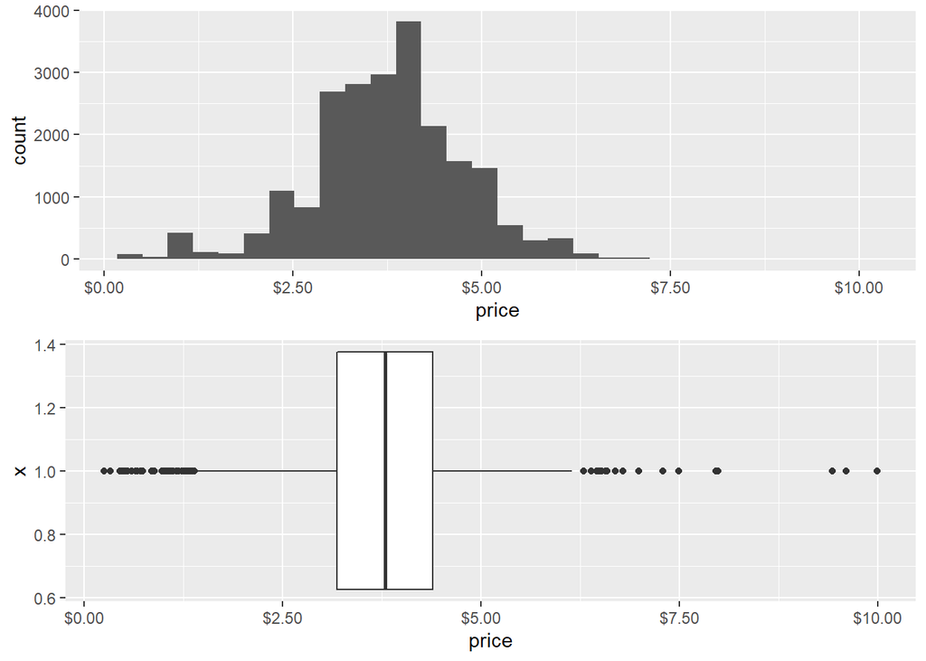

```r
# price
grid.arrange(
  # add histogram
  ggplot(data = cereal_ps, mapping = aes(x = price)) +
    geom_histogram() +
    scale_x_continuous(labels = dollar),

  # add boxplot
  ggplot(data = cereal_ps, mapping = aes(x = 1)) +
    geom_boxplot(mapping = aes(y = price)) +
    scale_y_continuous(labels = dollar) +
    coord_flip()
)
```

**Comments**

```
- outliers of 9.99 throwing off the data
- median at $3.79
```

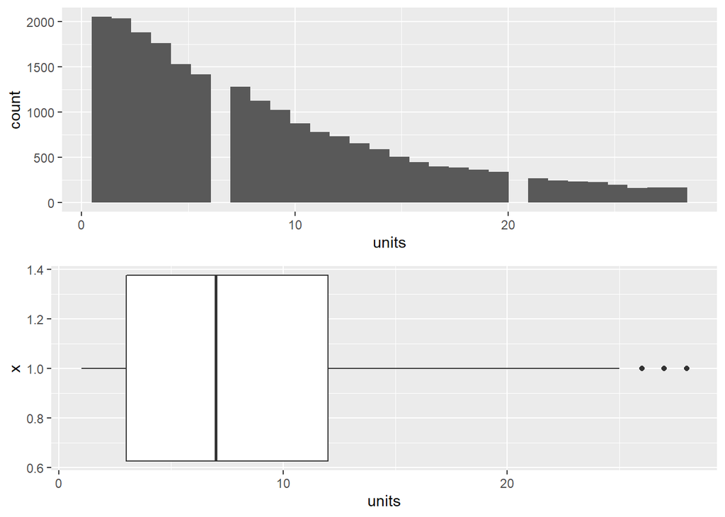

```r
# units
grid.arrange(
  # add histogram
  ggplot(data = cereal_ps, mapping = aes(x = units)) +
    geom_histogram(),

  # add boxplot
  ggplot(data = cereal_ps, mapping = aes(x = 1)) +
    geom_boxplot(mapping = aes(y = units)) +
    coord_flip()
)
```

**Comments**

```
- consistent negative relationship between count and units
```

```r
#standard counts
cereal_ps %>%
  tabyl(units, flavor) %>% # creates table of counts
  adorn_totals(where = c("row", "col")) %>%
  kable() %>%
  kable_styling(bootstrap_options = "striped")
```

| units | Cinnamon Toast | Cocoa | Fruit | Regular | Toasted | Total |
| --- | --- | --- | --- | --- | --- | --- |
| 1 | 114 | 298 | 365 | 802 | 472 | 2051 |
| 2 | 142 | 263 | 295 | 835 | 502 | 2037 |
| 3 | 161 | 205 | 232 | 775 | 506 | 1879 |
| 4 | 119 | 188 | 233 | 730 | 490 | 1760 |
| 5 | 144 | 140 | 158 | 625 | 462 | 1529 |
| 6 | 141 | 104 | 142 | 581 | 447 | 1415 |
| 7 | 128 | 103 | 118 | 516 | 416 | 1281 |
| 8 | 102 | 62 | 90 | 484 | 390 | 1128 |
| 9 | 95 | 74 | 82 | 413 | 359 | 1023 |
| 10 | 112 | 73 | 59 | 328 | 304 | 876 |
| 11 | 78 | 54 | 53 | 321 | 277 | 783 |
| 12 | 76 | 49 | 55 | 274 | 281 | 735 |
| 13 | 68 | 32 | 40 | 263 | 253 | 656 |
| 14 | 52 | 32 | 40 | 251 | 215 | 590 |
| 15 | 31 | 20 | 41 | 200 | 214 | 506 |
| 16 | 40 | 24 | 25 | 189 | 170 | 448 |
| 17 | 26 | 22 | 21 | 156 | 172 | 397 |
| 18 | 31 | 24 | 19 | 162 | 150 | 386 |
| 19 | 34 | 14 | 21 | 144 | 151 | 364 |
| 20 | 20 | 19 | 20 | 141 | 139 | 339 |
| 21 | 21 | 16 | 17 | 102 | 111 | 267 |
| 22 | 13 | 19 | 12 | 103 | 96 | 243 |
| 23 | 22 | 14 | 10 | 82 | 103 | 231 |
| 24 | 17 | 9 | 10 | 84 | 110 | 230 |
| 25 | 10 | 18 | 10 | 74 | 88 | 200 |
| 26 | 11 | 12 | 7 | 63 | 70 | 163 |
| 27 | 13 | 7 | 11 | 55 | 79 | 165 |
| 28 | 13 | 6 | 6 | 63 | 80 | 168 |
| Total | 1834 | 1901 | 2192 | 8816 | 7107 | 21850 |

```r
# Proportion contingency/cross table
cereal_ps %>%
  tabyl(units, flavor) %>% # creates table of counts
  adorn_totals(where = c("row", "col")) %>%  # Total margins
  adorn_percentages(denominator = "all") %>% # creates proportions
  adorn_rounding(2) %>%      # round decimals
  kable() %>%
  kable_styling(bootstrap_options = "striped")
```

| units | Cinnamon Toast | Cocoa | Fruit | Regular | Toasted | Total |
| --- | --- | --- | --- | --- | --- | --- |
| 1 | 0.01 | 0.01 | 0.02 | 0.04 | 0.02 | 0.09 |
| 2 | 0.01 | 0.01 | 0.01 | 0.04 | 0.02 | 0.09 |
| 3 | 0.01 | 0.01 | 0.01 | 0.04 | 0.02 | 0.09 |
| 4 | 0.01 | 0.01 | 0.01 | 0.03 | 0.02 | 0.08 |
| 5 | 0.01 | 0.01 | 0.01 | 0.03 | 0.02 | 0.07 |
| 6 | 0.01 | 0.00 | 0.01 | 0.03 | 0.02 | 0.06 |
| 7 | 0.01 | 0.00 | 0.01 | 0.02 | 0.02 | 0.06 |
| 8 | 0.00 | 0.00 | 0.00 | 0.02 | 0.02 | 0.05 |
| 9 | 0.00 | 0.00 | 0.00 | 0.02 | 0.02 | 0.05 |
| 10 | 0.01 | 0.00 | 0.00 | 0.02 | 0.01 | 0.04 |
| 11 | 0.00 | 0.00 | 0.00 | 0.01 | 0.01 | 0.04 |
| 12 | 0.00 | 0.00 | 0.00 | 0.01 | 0.01 | 0.03 |
| 13 | 0.00 | 0.00 | 0.00 | 0.01 | 0.01 | 0.03 |
| 14 | 0.00 | 0.00 | 0.00 | 0.01 | 0.01 | 0.03 |
| 15 | 0.00 | 0.00 | 0.00 | 0.01 | 0.01 | 0.02 |
| 16 | 0.00 | 0.00 | 0.00 | 0.01 | 0.01 | 0.02 |
| 17 | 0.00 | 0.00 | 0.00 | 0.01 | 0.01 | 0.02 |
| 18 | 0.00 | 0.00 | 0.00 | 0.01 | 0.01 | 0.02 |
| 19 | 0.00 | 0.00 | 0.00 | 0.01 | 0.01 | 0.02 |
| 20 | 0.00 | 0.00 | 0.00 | 0.01 | 0.01 | 0.02 |
| 21 | 0.00 | 0.00 | 0.00 | 0.00 | 0.01 | 0.01 |
| 22 | 0.00 | 0.00 | 0.00 | 0.00 | 0.00 | 0.01 |
| 23 | 0.00 | 0.00 | 0.00 | 0.00 | 0.00 | 0.01 |
| 24 | 0.00 | 0.00 | 0.00 | 0.00 | 0.01 | 0.01 |
| 25 | 0.00 | 0.00 | 0.00 | 0.00 | 0.00 | 0.01 |
| 26 | 0.00 | 0.00 | 0.00 | 0.00 | 0.00 | 0.01 |
| 27 | 0.00 | 0.00 | 0.00 | 0.00 | 0.00 | 0.01 |
| 28 | 0.00 | 0.00 | 0.00 | 0.00 | 0.00 | 0.01 |
| Total | 0.08 | 0.09 | 0.10 | 0.40 | 0.33 | 1.00 |

**Comments**

```
- Selling cereal 22+ package increments is rare
```

```r
# standard counts
cereal_ps %>%
  tabyl(units, company) %>% # creates table of counts
  adorn_totals(where = c("row", "col")) %>%
  kable() %>%
  kable_styling(bootstrap_options = "striped")
```

| units | General Mills | Kelloggs | Post | Total |
| --- | --- | --- | --- | --- |
| 1 | 485 | 1204 | 362 | 2051 |
| 2 | 500 | 1210 | 327 | 2037 |
| 3 | 557 | 1026 | 296 | 1879 |
| 4 | 518 | 997 | 245 | 1760 |
| 5 | 500 | 840 | 189 | 1529 |
| 6 | 470 | 778 | 167 | 1415 |
| 7 | 425 | 715 | 141 | 1281 |
| 8 | 371 | 645 | 112 | 1128 |
| 9 | 350 | 582 | 91 | 1023 |
| 10 | 346 | 458 | 72 | 876 |
| 11 | 285 | 429 | 69 | 783 |
| 12 | 286 | 394 | 55 | 735 |
| 13 | 251 | 354 | 51 | 656 |
| 14 | 220 | 332 | 38 | 590 |
| 15 | 173 | 283 | 50 | 506 |
| 16 | 171 | 249 | 28 | 448 |
| 17 | 142 | 226 | 29 | 397 |
| 18 | 145 | 213 | 28 | 386 |
| 19 | 154 | 184 | 26 | 364 |
| 20 | 134 | 183 | 22 | 339 |
| 21 | 112 | 144 | 11 | 267 |
| 22 | 101 | 128 | 14 | 243 |
| 23 | 91 | 126 | 14 | 231 |
| 24 | 102 | 119 | 9 | 230 |
| 25 | 82 | 110 | 8 | 200 |
| 26 | 73 | 83 | 7 | 163 |
| 27 | 78 | 77 | 10 | 165 |
| 28 | 67 | 94 | 7 | 168 |
| Total | 7189 | 12183 | 2478 | 21850 |

```r
# Proportion contingency/cross table
cereal_ps %>%
  tabyl(units, company) %>% # creates table of counts
  adorn_totals(where = c("row", "col")) %>%  # Total margins
  adorn_percentages(denominator = "all") %>% # creates proportions
  adorn_rounding(2) %>%      # round decimals
  kable() %>%
  kable_styling(bootstrap_options = "striped")
```

| units | General Mills | Kelloggs | Post | Total |
| --- | --- | --- | --- | --- |
| 1 | 0.02 | 0.06 | 0.02 | 0.09 |
| 2 | 0.02 | 0.06 | 0.01 | 0.09 |
| 3 | 0.03 | 0.05 | 0.01 | 0.09 |
| 4 | 0.02 | 0.05 | 0.01 | 0.08 |
| 5 | 0.02 | 0.04 | 0.01 | 0.07 |
| 6 | 0.02 | 0.04 | 0.01 | 0.06 |
| 7 | 0.02 | 0.03 | 0.01 | 0.06 |
| 8 | 0.02 | 0.03 | 0.01 | 0.05 |
| 9 | 0.02 | 0.03 | 0.00 | 0.05 |
| 10 | 0.02 | 0.02 | 0.00 | 0.04 |
| 11 | 0.01 | 0.02 | 0.00 | 0.04 |
| 12 | 0.01 | 0.02 | 0.00 | 0.03 |
| 13 | 0.01 | 0.02 | 0.00 | 0.03 |
| 14 | 0.01 | 0.02 | 0.00 | 0.03 |
| 15 | 0.01 | 0.01 | 0.00 | 0.02 |
| 16 | 0.01 | 0.01 | 0.00 | 0.02 |
| 17 | 0.01 | 0.01 | 0.00 | 0.02 |
| 18 | 0.01 | 0.01 | 0.00 | 0.02 |
| 19 | 0.01 | 0.01 | 0.00 | 0.02 |
| 20 | 0.01 | 0.01 | 0.00 | 0.02 |
| 21 | 0.01 | 0.01 | 0.00 | 0.01 |
| 22 | 0.00 | 0.01 | 0.00 | 0.01 |
| 23 | 0.00 | 0.01 | 0.00 | 0.01 |
| 24 | 0.00 | 0.01 | 0.00 | 0.01 |
| 25 | 0.00 | 0.01 | 0.00 | 0.01 |
| 26 | 0.00 | 0.00 | 0.00 | 0.01 |
| 27 | 0.00 | 0.00 | 0.00 | 0.01 |
| 28 | 0.00 | 0.00 | 0.00 | 0.01 |
| Total | 0.33 | 0.56 | 0.11 | 1.00 |

**Comments**

```
- GM struggles to compete with Kelloggs when selling median units
```

```r
# standard counts
units_price_count <- cereal_ps %>%
  tabyl(units, price) %>% # creates table of counts
  adorn_totals(where = c("row", "col"))

head(units_price_count, 5)
```

| units | 0.25 | 0.33 | 0.45 | 0.47 | 0.48 | 0.5 | 0.52 | 0.53 | 0.54 | 0.55 | 0.6 | 0.65 | 0.66 | 0.67 | 0.71 | 0.74 | 0.85 | 0.89 | 0.98 | 0.99 | 1 | 1.01 | 1.02 | 1.03 | 1.04 | 1.05 | 1.06 | 1.09 | 1.1 | … |
| --- | --- | --- | --- | --- | --- | --- | --- | --- | --- | --- | --- | --- | --- | --- | --- | --- | --- | --- | --- | --- | --- | --- | --- | --- | --- | --- | --- | --- | --- | --- |
| 1 | 0 | 0 | 0 | 0 | 1 | 3 | 0 | 0 | 2 | 3 | 0 | 0 | 0 | 1 | 0 | 0 | 0 | 0 | 0 | 5 | 16 | 1 | 0 | 0 | 0 | 2 | 0 | 7 | 0 | … |
| 2 | 1 | 0 | 0 | 0 | 0 | 7 | 0 | 0 | 0 | 1 | 0 | 0 | 2 | 0 | 0 | 0 | 0 | 2 | 0 | 9 | 18 | 0 | 0 | 0 | 0 | 0 | 0 | 1 | 0 | … |
| 3 | 1 | 1 | 0 | 1 | 0 | 2 | 0 | 0 | 0 | 1 | 0 | 0 | 0 | 1 | 0 | 0 | 0 | 0 | 0 | 4 | 25 | 0 | 0 | 0 | 0 | 0 | 0 | 3 | 0 | … |
| 4 | 0 | 0 | 0 | 0 | 0 | 2 | 0 | 0 | 0 | 3 | 0 | 0 | 0 | 1 | 0 | 0 | 1 | 0 | 0 | 3 | 14 | 1 | 0 | 0 | 0 | 0 | 0 | 9 | 0 | … |
| 5 | 0 | 0 | 1 | 1 | 0 | 7 | 0 | 0 | 0 | 1 | 0 | 1 | 0 | 1 | 0 | 0 | 0 | 0 | 0 | 5 | 23 | 0 | 0 | 0 | 0 | 1 | 0 | 4 | 0 | … |

```r
# Proportion contingency/cross table
units_price_prop <- cereal_ps %>%
  tabyl(units, price) %>% # creates table of counts
  adorn_totals(where = c("row", "col")) %>%  # Total margins
  adorn_percentages(denominator = "all") %>% # creates proportions
  adorn_rounding(2)      # round decimals

head(units_price_prop, 5)
```

| units | 0.25 | 0.33 | 0.45 | 0.47 | 0.48 | 0.5 | 0.52 | 0.53 | 0.54 | 0.55 | 0.6 | 0.65 | 0.66 | 0.67 | 0.71 | 0.74 | 0.85 | 0.89 | 0.98 | 0.99 | 1 | 1.01 | 1.02 | 1.03 | 1.04 | 1.05 | 1.06 | 1.09 | 1.1 | … |
| --- | --- | --- | --- | --- | --- | --- | --- | --- | --- | --- | --- | --- | --- | --- | --- | --- | --- | --- | --- | --- | --- | --- | --- | --- | --- | --- | --- | --- | --- | --- |
| 1 | 0 | 0 | 0 | 0 | 0 | 0 | 0 | 0 | 0 | 0 | 0 | 0 | 0 | 0 | 0 | 0 | 0 | 0 | 0 | 0 | 0 | 0 | 0 | 0 | 0 | 0 | 0 | 0 | 0 | … |
| 2 | 0 | 0 | 0 | 0 | 0 | 0 | 0 | 0 | 0 | 0 | 0 | 0 | 0 | 0 | 0 | 0 | 0 | 0 | 0 | 0 | 0 | 0 | 0 | 0 | 0 | 0 | 0 | 0 | 0 | … |
| 3 | 0 | 0 | 0 | 0 | 0 | 0 | 0 | 0 | 0 | 0 | 0 | 0 | 0 | 0 | 0 | 0 | 0 | 0 | 0 | 0 | 0 | 0 | 0 | 0 | 0 | 0 | 0 | 0 | 0 | … |
| 4 | 0 | 0 | 0 | 0 | 0 | 0 | 0 | 0 | 0 | 0 | 0 | 0 | 0 | 0 | 0 | 0 | 0 | 0 | 0 | 0 | 0 | 0 | 0 | 0 | 0 | 0 | 0 | 0 | 0 | … |
| 5 | 0 | 0 | 0 | 0 | 0 | 0 | 0 | 0 | 0 | 0 | 0 | 0 | 0 | 0 | 0 | 0 | 0 | 0 | 0 | 0 | 0 | 0 | 0 | 0 | 0 | 0 | 0 | 0 | 0 | … |

### 5.2.2 Units and Volume

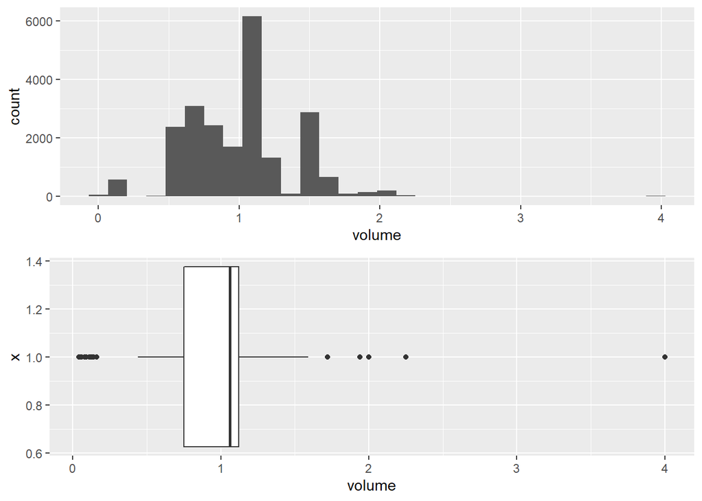

```r
# volume
grid.arrange(
  # add histogram
  ggplot(data = cereal_ps, mapping = aes(x = volume)) +
    geom_histogram(),

  # add boxplot
  ggplot(data = cereal_ps, mapping = aes(x = 1)) +
    geom_boxplot(mapping = aes(y = volume)) +
    coord_flip()
)
```

**Comments**

```
- Median volume is 1.06
```

```r
# standard counts
units_vol_count <- cereal_ps %>%
  tabyl(units, volume) %>% # creates table of counts
  adorn_totals(where = c("row", "col"))

head(units_vol_count, 10)
```

| units | 0.04 | 0.05 | 0.06 | 0.08 | 0.09 | 0.11 | 0.12 | 0.13 | 0.14 | 0.16 | 0.44 | 0.54 | 0.55 | 0.56 | 0.62 | 0.69 | 0.72 | 0.74 | 0.75 | 0.76 | 0.78 | 0.79 | 0.8 | 0.81 | 0.86 | 0.87 | 0.88 | 0.89 | 0.93 | … |
| --- | --- | --- | --- | --- | --- | --- | --- | --- | --- | --- | --- | --- | --- | --- | --- | --- | --- | --- | --- | --- | --- | --- | --- | --- | --- | --- | --- | --- | --- | --- |
| 1 | 0 | 0 | 5 | 21 | 11 | 5 | 1 | 10 | 0 | 2 | 3 | 72 | 292 | 27 | 1 | 38 | 26 | 59 | 87 | 31 | 28 | 10 | 21 | 112 | 3 | 5 | 29 | 17 | 1 | … |
| 2 | 2 | 0 | 4 | 16 | 7 | 4 | 8 | 16 | 0 | 4 | 3 | 78 | 226 | 28 | 0 | 35 | 31 | 44 | 101 | 27 | 25 | 17 | 29 | 73 | 0 | 4 | 52 | 12 | 3 | … |
| 3 | 1 | 0 | 4 | 16 | 7 | 4 | 2 | 12 | 0 | 4 | 7 | 61 | 143 | 30 | 0 | 15 | 39 | 52 | 122 | 33 | 18 | 14 | 52 | 56 | 0 | 5 | 44 | 6 | 1 | … |
| 4 | 1 | 0 | 3 | 14 | 7 | 5 | 5 | 11 | 0 | 5 | 2 | 54 | 113 | 38 | 0 | 29 | 41 | 63 | 125 | 25 | 6 | 14 | 36 | 30 | 0 | 5 | 55 | 2 | 2 | … |
| 5 | 1 | 0 | 5 | 22 | 8 | 4 | 4 | 6 | 0 | 1 | 1 | 42 | 67 | 42 | 0 | 14 | 36 | 48 | 127 | 27 | 10 | 9 | 34 | 20 | 1 | 0 | 42 | 5 | 0 | … |
| 6 | 1 | 0 | 7 | 7 | 5 | 1 | 7 | 14 | 0 | 3 | 1 | 36 | 56 | 39 | 0 | 15 | 38 | 39 | 108 | 17 | 11 | 5 | 40 | 15 | 0 | 3 | 59 | 9 | 0 | … |
| 7 | 0 | 0 | 2 | 12 | 4 | 6 | 6 | 8 | 1 | 3 | 1 | 30 | 40 | 50 | 0 | 16 | 32 | 38 | 95 | 19 | 5 | 6 | 36 | 11 | 0 | 2 | 50 | 1 | 2 | … |
| 8 | 1 | 0 | 4 | 9 | 4 | 4 | 2 | 6 | 0 | 3 | 0 | 25 | 25 | 28 | 0 | 11 | 30 | 22 | 110 | 13 | 4 | 3 | 35 | 5 | 0 | 2 | 55 | 3 | 0 | … |
| 9 | 0 | 0 | 2 | 9 | 8 | 1 | 4 | 9 | 0 | 1 | 0 | 26 | 20 | 34 | 0 | 8 | 24 | 32 | 88 | 14 | 2 | 3 | 25 | 5 | 0 | 1 | 49 | 0 | 0 | … |
| 10 | 0 | 0 | 4 | 7 | 2 | 4 | 6 | 6 | 0 | 4 | 0 | 15 | 17 | 34 | 0 | 4 | 27 | 34 | 75 | 9 | 4 | 2 | 24 | 4 | 0 | 4 | 39 | 3 | 0 | … |

```r
# Proportion contingency/cross table
units_vol_prop <- cereal_ps %>%
  tabyl(units, volume) %>% # creates table of counts
  adorn_totals(where = c("row", "col")) %>%  # Total margins
  adorn_percentages(denominator = "all") %>% # creates proportions
  adorn_rounding(2)     # round decimals

head(units_vol_prop, 10)
```

| units | 0.04 | 0.05 | 0.06 | 0.08 | 0.09 | 0.11 | 0.12 | 0.13 | 0.14 | 0.16 | 0.44 | 0.54 | 0.55 | 0.56 | 0.62 | 0.69 | 0.72 | 0.74 | 0.75 | 0.76 | 0.78 | 0.79 | 0.8 | 0.81 | 0.86 | 0.87 | 0.88 | 0.89 | 0.93 | … |
| --- | --- | --- | --- | --- | --- | --- | --- | --- | --- | --- | --- | --- | --- | --- | --- | --- | --- | --- | --- | --- | --- | --- | --- | --- | --- | --- | --- | --- | --- | --- |
| 1 | 0 | 0 | 0 | 0 | 0 | 0 | 0 | 0 | 0 | 0 | 0 | 0 | 0.01 | 0 | 0 | 0 | 0 | 0 | 0 | 0 | 0 | 0 | 0 | 0.01 | 0 | 0 | 0 | 0 | 0 | … |
| 2 | 0 | 0 | 0 | 0 | 0 | 0 | 0 | 0 | 0 | 0 | 0 | 0 | 0.01 | 0 | 0 | 0 | 0 | 0 | 0 | 0 | 0 | 0 | 0 | 0 | 0 | 0 | 0 | 0 | 0 | … |
| 3 | 0 | 0 | 0 | 0 | 0 | 0 | 0 | 0 | 0 | 0 | 0 | 0 | 0.01 | 0 | 0 | 0 | 0 | 0 | 0.01 | 0 | 0 | 0 | 0 | 0 | 0 | 0 | 0 | 0 | 0 | … |
| 4 | 0 | 0 | 0 | 0 | 0 | 0 | 0 | 0 | 0 | 0 | 0 | 0 | 0.01 | 0 | 0 | 0 | 0 | 0 | 0.01 | 0 | 0 | 0 | 0 | 0 | 0 | 0 | 0 | 0 | 0 | … |
| 5 | 0 | 0 | 0 | 0 | 0 | 0 | 0 | 0 | 0 | 0 | 0 | 0 | 0 | 0 | 0 | 0 | 0 | 0 | 0.01 | 0 | 0 | 0 | 0 | 0 | 0 | 0 | 0 | 0 | 0 | … |
| 6 | 0 | 0 | 0 | 0 | 0 | 0 | 0 | 0 | 0 | 0 | 0 | 0 | 0 | 0 | 0 | 0 | 0 | 0 | 0 | 0 | 0 | 0 | 0 | 0 | 0 | 0 | 0 | 0 | 0 | … |
| 7 | 0 | 0 | 0 | 0 | 0 | 0 | 0 | 0 | 0 | 0 | 0 | 0 | 0 | 0 | 0 | 0 | 0 | 0 | 0 | 0 | 0 | 0 | 0 | 0 | 0 | 0 | 0 | 0 | 0 | … |
| 8 | 0 | 0 | 0 | 0 | 0 | 0 | 0 | 0 | 0 | 0 | 0 | 0 | 0 | 0 | 0 | 0 | 0 | 0 | 0.01 | 0 | 0 | 0 | 0 | 0 | 0 | 0 | 0 | 0 | 0 | … |
| 9 | 0 | 0 | 0 | 0 | 0 | 0 | 0 | 0 | 0 | 0 | 0 | 0 | 0 | 0 | 0 | 0 | 0 | 0 | 0 | 0 | 0 | 0 | 0 | 0 | 0 | 0 | 0 | 0 | 0 | … |
| 10 | 0 | 0 | 0 | 0 | 0 | 0 | 0 | 0 | 0 | 0 | 0 | 0 | 0 | 0 | 0 | 0 | 0 | 0 | 0 | 0 | 0 | 0 | 0 | 0 | 0 | 0 | 0 | 0 | 0 | … |

### 5.2.3 Correlation Plot

```r
cor_cereal <- cereal_ps %>%
  select_if(is.numeric) %>%   # Use to select just the numeric variables
  cor() %>%
  round(2)

cor_cereal
```

```
##         volume iri_key  week units price promo
## volume    1.00   -0.01 -0.02  0.02  0.54 -0.05
## iri_key  -0.01    1.00  0.01  0.03 -0.01 -0.02
## week     -0.02    0.01  1.00 -0.03  0.03 -0.02
## units     0.02    0.03 -0.03  1.00 -0.19  0.20
## price     0.54   -0.01  0.03 -0.19  1.00 -0.41
## promo    -0.05   -0.02 -0.02  0.20 -0.41  1.00
```

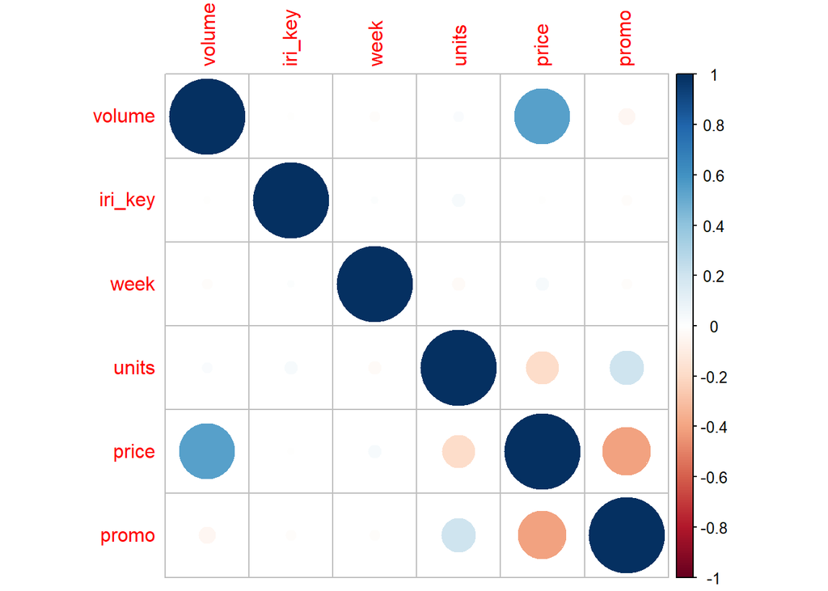

```r
# use corrplot for correlation matrix
corrplot(cor_cereal)
```

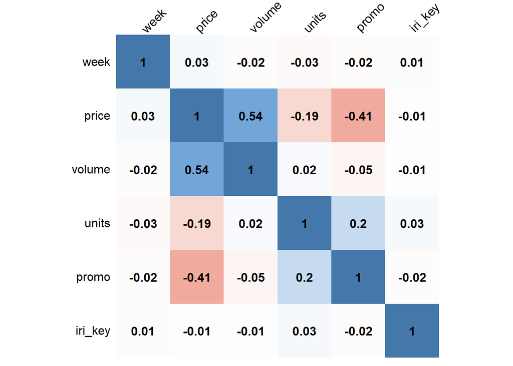

```r
# use different color scheme and add numbers to each square
col <- colorRampPalette(c("#BB4444", "#EE9988", "#FFFFFF", "#77AADD", "#4477AA"))

corrplot(cor_cereal, method = "shade", shade.col = NA, tl.col = "black", tl.srt = 45,
         col = col(200), addCoef.col = "black", cl.pos = "n", order = "AOE")
```

**Comments**

- price and promo are negatively correlated
- volume and price are positively correlated
- units and price are negatively correlated
- Remaining correlations are quite weak (close to 0)

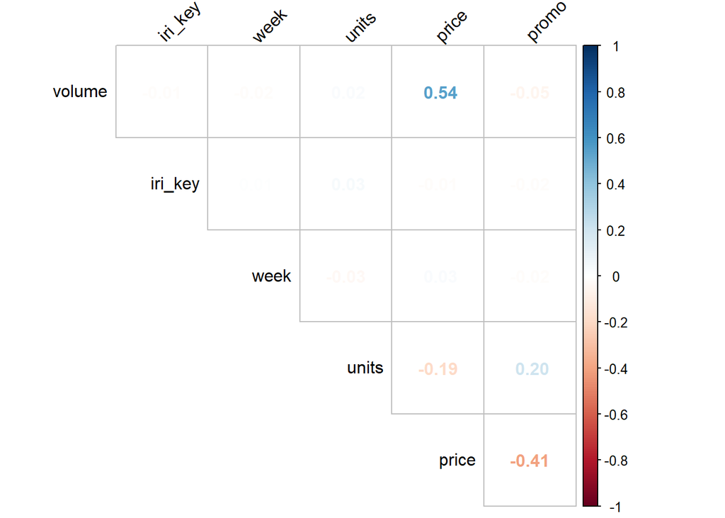

```r
cor_cereal <- cereal_ps %>%
  select_if(is.numeric) %>%   # Use to select just the numeric variables
  cor()

corrplot(cor_cereal,
         method = "number",
         sig.level = 0.05,
         order = "original",
         diag = FALSE,
         type = "upper",
         tl.srt = 45,
         tl.col = "black")
```

**Comments**

```
- Very subtle correlations, nothing super definitive
```

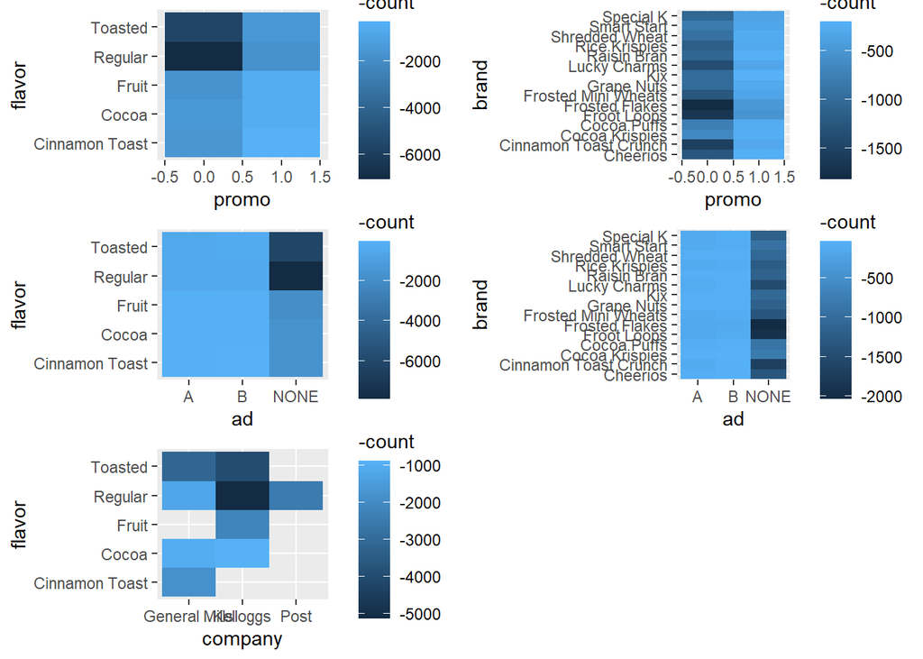

```r
# Tile graph - need count
grid.arrange(
  # tile graph on promo and flavor
  cereal_ps %>%
  group_by(promo, flavor) %>%
  summarize(count = n()) %>%
  ggplot(aes(promo, flavor)) +
  geom_tile(aes(fill = -count)),
  # tile graph on promo and brand
  cereal_ps %>%
  group_by(promo, brand) %>%
  summarize(count = n()) %>%
  ggplot(aes(promo, brand)) +
  geom_tile(aes(fill = -count)),
  # tile graph on ad and flavor
  cereal_ps %>%
  group_by(ad, flavor) %>%
  summarize(count = n()) %>%
  ggplot(aes(ad, flavor)) +
  geom_tile(aes(fill = -count)),
  # tile graph on ad and brand
  cereal_ps %>%
  group_by(ad, brand) %>%
  summarize(count = n()) %>%
  ggplot(aes(ad, brand)) +
  geom_tile(aes(fill = -count)),
  # tile graph on flavor and company
  cereal_ps %>%
  group_by(company, flavor) %>%
  summarize(count = n()) %>%
  ggplot(aes(company, flavor)) +
  geom_tile(aes(fill = -count))

)
```

**Comments**

```
- Flavor: Toasted and Regular are the highest sellers with no promo
- Flavor: Toasted and Regular are the highest sllers with no ads
- Brand: Frosted Flakes, Froot Loops, and Cinnamon Tst Crunch are highest sellers with no promo
- Brand: Frosted Flakes, Froot Loops, and Cinnamon Tst Crunch are highest sellers with no ads
- Flavor: GM has a gap in Fruit flavor offering.
    - If GM had a Fruit flavor to offer, we could compete with Kelloggs
- Flavor: GM has monopoly on Cinnamon Toast flavor
```

**Questions**

- do ads and promos have any effect on cereal sales at all?
  - Ho: Ads do not have an effect on cereal sales
  - Ho: Promos do not have an effect on cereal sales
    - Need to do a chi-squared test for these since dealing with categorical data

# 6 Base EDA Step 4: Multi-variate graphical

## 6.1 Step 4.1: Categorical

- Bar graphs with multiple categorical variables

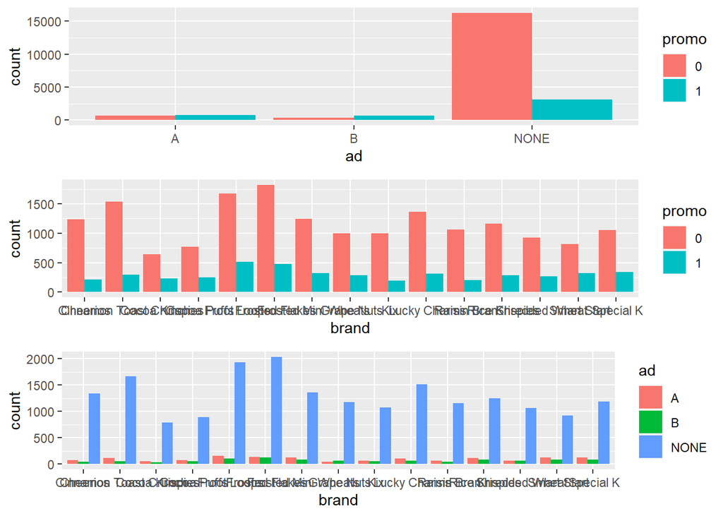

```r
grid.arrange(
  cereal_ps %>%
    mutate(promo = as.factor(promo)) %>%
    ggplot(mapping = aes(x = ad, fill = promo)) +
    geom_bar(position = "dodge"),

cereal_ps %>%
  mutate(promo = as.factor(promo)) %>%
  ggplot(mapping = aes(x = brand, fill = promo)) +
  geom_bar(position = "dodge"),

cereal_ps %>%
  mutate(promo = as.factor(ad)) %>%
    ggplot(mapping = aes(x = brand, fill = ad)) +
    geom_bar(position = "dodge"),

ncol = 1)
```

**Comments**

```
- no promo and no ad is the highest seller
- cereal sells more with no promo
```

**Questions**

- Why should companies spend money on ads and promos?
  - It seems like cereal will sell itself

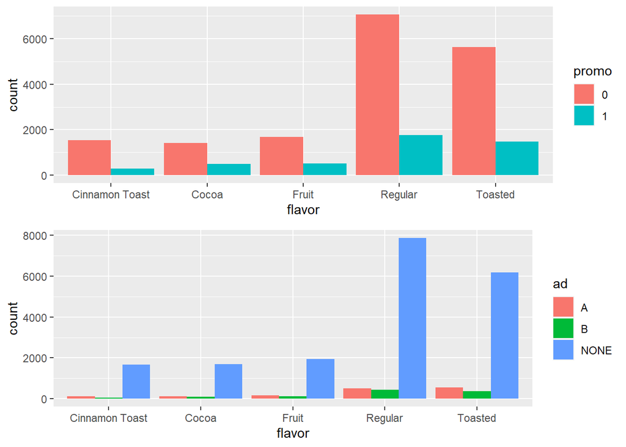

```r
grid.arrange(
cereal_ps %>%
  mutate(promo = as.factor(promo)) %>%
    ggplot(mapping = aes(x = flavor, fill = promo)) +
    geom_bar(position = "dodge"),

cereal_ps %>%
  mutate(promo = as.factor(ad)) %>%
    ggplot(mapping = aes(x = flavor, fill = ad)) +
    geom_bar(position = "dodge"),

ncol = 1)
```

**Comments**

```
- when there are ads and promos in effect, it appears that promos happen almost half the time that adds do
- brands are selling just fine without adds or promotions, as this is the majority of our data
- Flavor sales may or may not be impacted by promotions
```

**Questions**

- What benefit is there to spending budget on ads and promos?

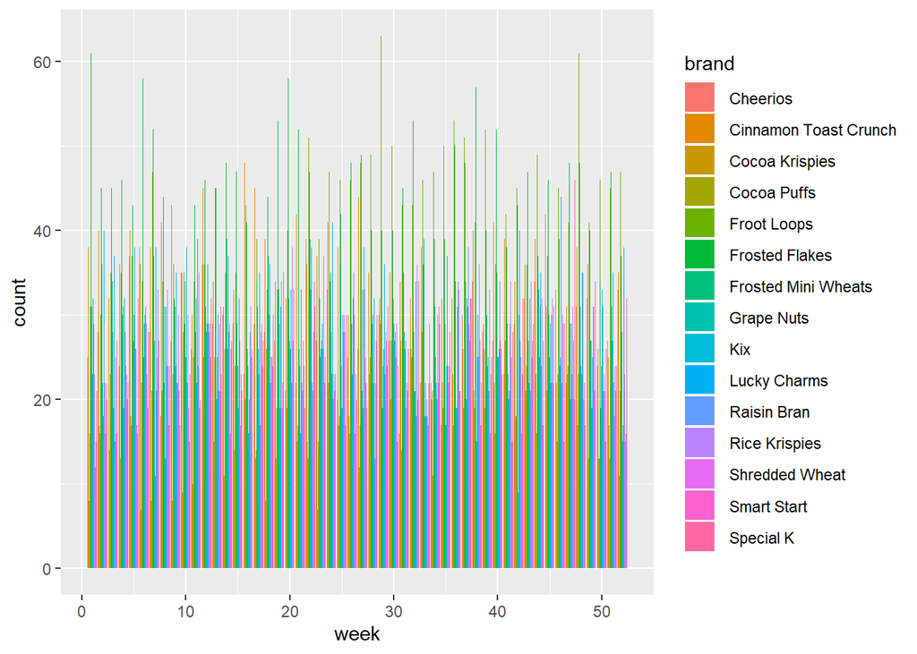

```r
grid.arrange(
cereal_ps %>%
  mutate(brand = as.factor(brand)) %>%
    ggplot(mapping = aes(x = week, fill = brand)) +
    geom_bar(position = "dodge"),

ncol = 1)
```

**Comments**

```
- sales of each brand appear to be consistent for the whole year
```

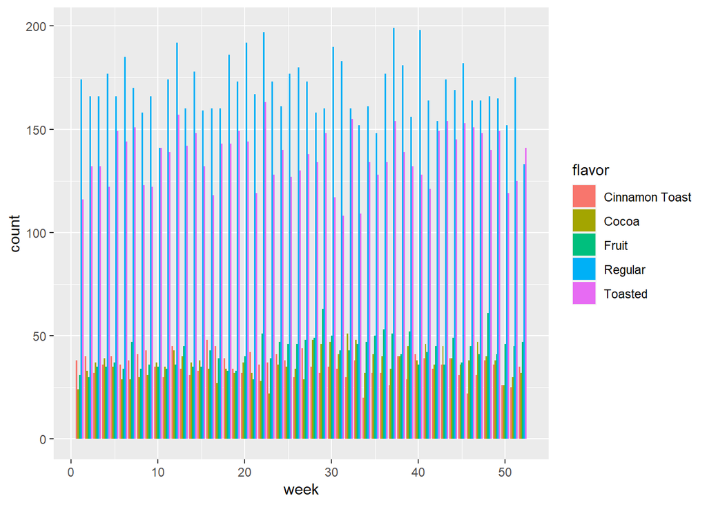

```r
grid.arrange(
cereal_ps %>%
  mutate(promo = as.factor(flavor)) %>%
    ggplot(mapping = aes(x = week, fill = flavor)) +
    geom_bar(position = "dodge"),

ncol = 1)
```

**Comments**

```
- weekly sales are steady for flavor and brand over time with minimal change.
- Regular and toasted are always the weekly top sellers
```

**Questions**

- do ads or promos occasionally have an inverse relationship with sales?
- for a store that does run adds or promotions do they sell more typically than stores that don’t?
- how do adds impact company and brand sales over time?

## 6.2 Step 4.2: Quantitative

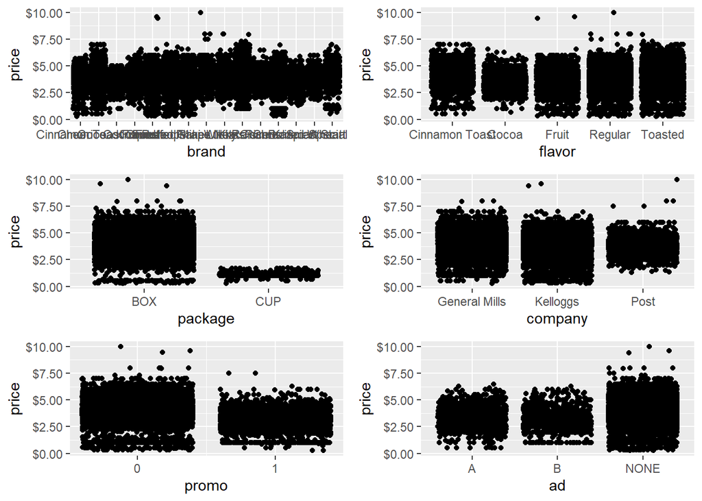

```r
# Code scatterplots using grid.arrange so can see all quant variables together
grid.arrange(
  # price on brand
  cereal_ps %>%
    ggplot(mapping = aes(x = brand, y = price)) +
    geom_point(position = "jitter") +
    scale_y_continuous(labels = dollar),

  # price on flavor
  cereal_ps %>%
    ggplot(mapping = aes(x = flavor, y = price)) +
    geom_point(position = "jitter") +
    scale_y_continuous(labels = dollar),

  # price on package
  cereal_ps %>%
    ggplot(mapping = aes(x = package, y = price)) +
    geom_point(position = "jitter") +    # can't see points all on a single line. Jitter helps see multiple points on same point
    scale_y_continuous(labels = dollar),

  # price on company
  cereal_ps %>%
    ggplot(mapping = aes(x = company, y = price)) +
    geom_point(position = "jitter") +
    scale_y_continuous(labels = dollar),

  # price on promo
  cereal_ps %>%
    ggplot(mapping = aes(x = promo, y = price)) +
    geom_point(position = "jitter") +
    scale_y_continuous(labels = dollar) +
    scale_x_continuous(breaks = c(0, 1)),

  # price on ad
  cereal_ps %>%
    ggplot(mapping = aes(x = ad, y = price)) +
    geom_point(position = "jitter") +
    scale_y_continuous(labels = dollar),

  ncol = 2
)
```

**Comments**

[output not shown]

**Questions**

- What is the median price point between companies?

## 6.3 Step 4.3: Categorical and quantitative

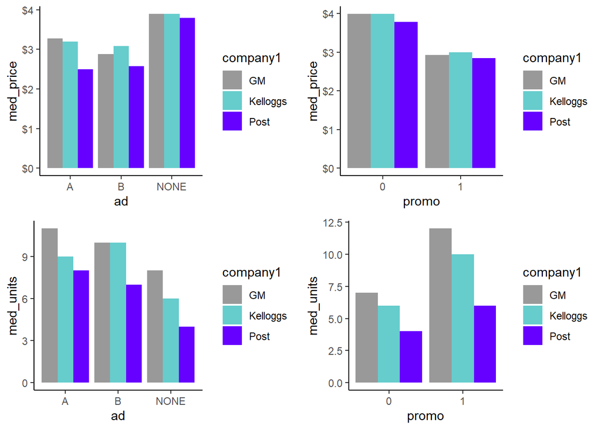

```r
cereal_numeric <- cereal_ps %>%
  mutate(company1 = case_when(
    str_starts(company, 'General') ~ 'GM',
    str_starts(company, 'Kelloggs') ~ 'Kelloggs',
    str_starts(company, 'Post') ~ 'Post'))

cb_palette <- c("#999999", "#66CCCC", "#6600FF")

grid.arrange(
cereal_numeric %>%
  mutate(company1 = as.factor(company1)) %>%
  group_by(ad, company1) %>%
  summarise(med_price = median(price)) %>%
  ggplot(mapping = aes(x = ad, y = med_price, fill = company1)) +
  scale_fill_manual(values = cb_palette) +
  geom_bar(stat = "identity", position = "dodge", guide = guide_legend(reverse = TRUE)) +
  theme_classic() +
  scale_y_continuous(labels = dollar),

cereal_numeric %>%
  mutate(company1 = as.factor(company1)) %>%
  group_by(promo, company1) %>%
  summarise(med_price = median(price)) %>%
  ggplot(mapping = aes(x = promo, y = med_price, fill = company1)) +
  scale_fill_manual(values = cb_palette) +
  geom_bar(stat = "identity", position = "dodge", guide = guide_legend(reverse = TRUE)) +
  theme_classic() +
  scale_y_continuous(labels = dollar) +
  scale_x_continuous(breaks = c(0, 1)),

cereal_numeric %>%
  mutate(company1 = as.factor(company1)) %>%
  group_by(ad, company1) %>%
  summarise(med_units = median(units)) %>%
  ggplot(mapping = aes(x = ad, y = med_units, fill = company1)) +
  scale_fill_manual(values = cb_palette) +
  geom_bar(stat = "identity", position = "dodge", guide = guide_legend(reverse = TRUE)) +
  theme_classic(),

cereal_numeric %>%
  mutate(company1 = as.factor(company1)) %>%
  group_by(promo, company1) %>%
  summarise(med_units = median(units)) %>%
  ggplot(mapping = aes(x = promo, y = med_units, fill = company1)) +
  scale_fill_manual(values = cb_palette) +
  geom_bar(stat = "identity", position = "dodge", guide = guide_legend(reverse = TRUE)) +
  theme_classic() +
  scale_x_continuous(breaks = c(0, 1)),

ncol = 2)
```

**Comments**

[output not shown]

**Questions**

- Perhaps a strategy could be to lower the price of GM cereals to boost sales?
- Is doing a promotion truly worth doing for general mills?
  - They sell another 80% more in units, but is the 25% cost drop worth it?
- Which ad campaign is preferable?
  - ad campaign A appears to be preferable for GM
- Which company benefits the most from a promotion
  - GM benefits the most from promotions
- Which company benefits most from a small ad campaign?
  - GM benefits the most from campaign A

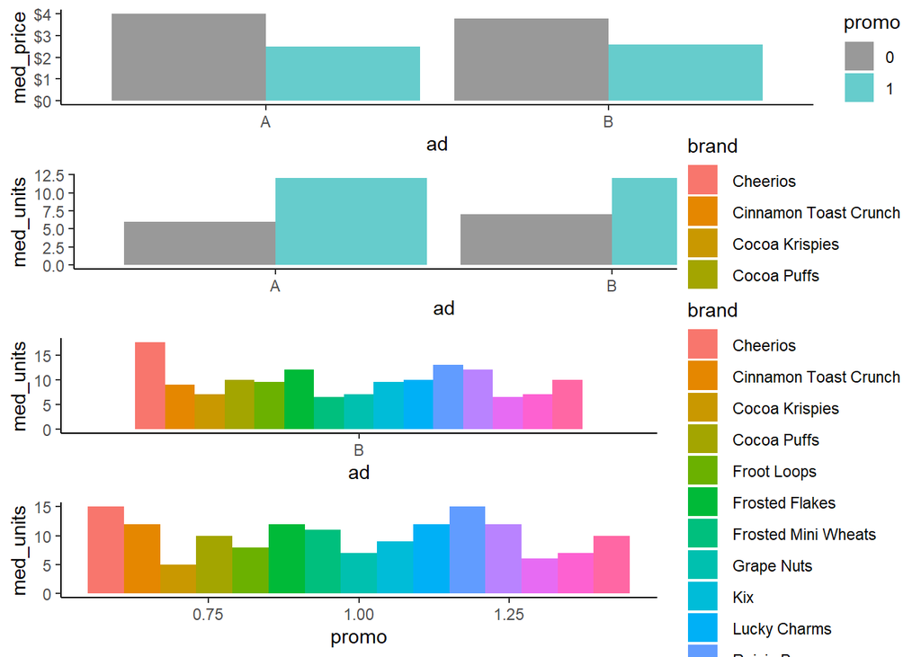

```r
cereal_numeric <- cereal_ps %>%
  mutate(company1 = case_when(
    str_starts(company, 'General') ~ 1,
    str_starts(company, 'Kelloggs') ~ 2,
    str_starts(company, 'Post') ~ 3))

cb_palette <- c("#999999", "#66CCCC", "#6600FF")
ad1 <- c('A', 'B')
ad2 <- c('B')

grid.arrange(

cereal_numeric %>%
  mutate(promo = as.factor(promo)) %>%
  filter(ad %in% ad1) %>%
  group_by(ad, promo) %>%
  summarise(med_price = median(price)) %>%
  ggplot(mapping = aes(x = ad, y = med_price, fill = promo)) +
  scale_fill_manual(values = cb_palette) +
  geom_bar(stat = "identity", position = "dodge", guide = guide_legend(reverse = TRUE)) +
  theme_classic()  +
  scale_y_continuous(labels = scales :: dollar),

cereal_numeric %>%
  mutate(promo = as.factor(promo)) %>%
  filter(ad %in% ad1) %>%
  group_by(ad, promo) %>%
  summarise(med_units = median(units)) %>%
  ggplot(mapping = aes(x = ad, y = med_units, fill = promo)) +
  scale_fill_manual(values = cb_palette) +
  geom_bar(stat = "identity", position = "dodge", guide = guide_legend(reverse = TRUE)) +
  theme_classic(),

# filter
cereal_numeric %>%
  mutate(brand = as.factor(brand)) %>%
  filter(ad %in% ad2) %>%
  group_by(ad, brand) %>%
  summarise(med_units = median(units)) %>%
  ggplot(mapping = aes(x = ad, y = med_units, fill = brand)) +
  geom_bar(stat = "identity", position = "dodge", guide = guide_legend(reverse = TRUE)) +
  theme_classic(),

cereal_numeric %>%
  mutate(brand = as.factor(brand)) %>%
  filter(promo == 1) %>%
  group_by(promo, brand) %>%
  summarise(med_units = median(units)) %>%
  ggplot(mapping = aes(x = promo, y = med_units, fill = brand)) +
  geom_bar(stat = "identity", position = "dodge") +
  guides(labels = "none") +
  theme_classic(),

ncol = 1)
```

**Comments**

[output not shown]

**Questions**

- How much does each brand actually benefit from the promotion or ad
- Why are other brands not selling more on add or promotion?

# 7 Detailed EDA Questions Raised in Base EDA

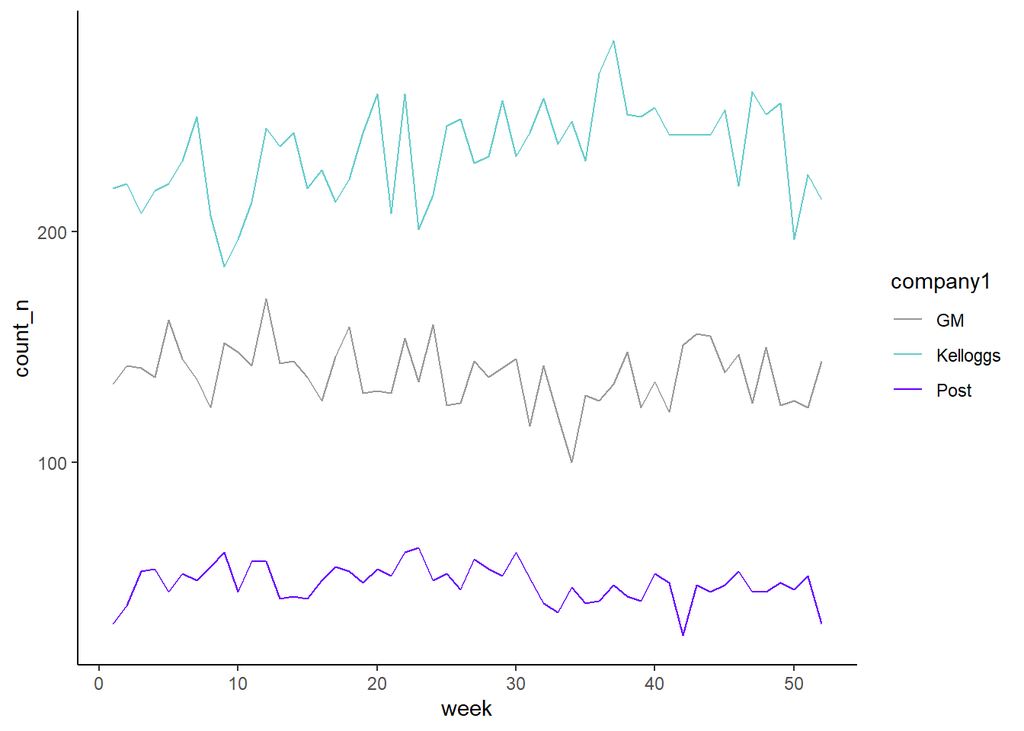

```r
cb_palette <- c("#999999", "#66CCCC", "#6600FF")

cereal_numeric <- cereal_ps %>%
  mutate(company1 = case_when(
    str_starts(company, 'General') ~ "GM",
    str_starts(company, 'Kelloggs') ~ "Kelloggs",
    str_starts(company, 'Post') ~ "Post"))

#stores that do promotions (==1) vs stores that don't (==0)
#trying to plot just two lines, one showing the total sales from stores that do use promos and stores that don't
stores_weekly <- cereal_numeric %>%
  mutate(company1 = as.factor(company1)) %>%
  group_by(week, company1) %>%
  summarise(count_n = n()) %>%
  ggplot(mapping = aes(x = week, y = count_n, color = company1, legend = "none")) +
  scale_color_manual(values = cb_palette) +
  geom_line() +
  theme_classic()
stores_weekly
```

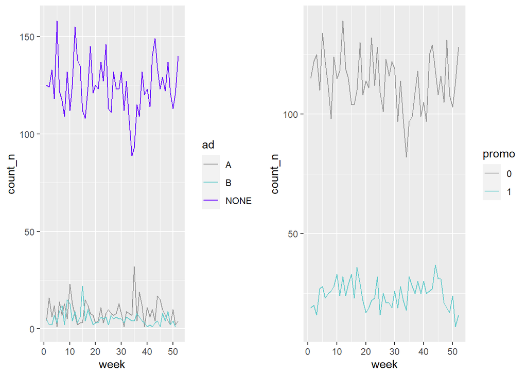

```r
cb_palette <- c("#999999", "#66CCCC", "#6600FF")

promo_weekly <- cereal_numeric %>%
  mutate(promo = as.factor(promo)) %>%
  filter(company == 'General Mills') %>%
  group_by(week, promo) %>%
  summarise(count_n = n()) %>%
  ggplot(mapping = aes(x = week, y = count_n, color = promo, legend = "none")) +
  scale_color_manual(values = cb_palette) +
  geom_line()
ad_weekly <- cereal_numeric %>%
  mutate(ad = as.factor(ad)) %>%
  filter(company == 'General Mills') %>%
  group_by(week, ad) %>%
  summarise(count_n = n()) %>%
  ggplot(mapping = aes(x = week, y = count_n, color = ad, legend = "none")) +
  scale_color_manual(values = cb_palette) +
  geom_line()
grid.arrange(
ad_weekly,
promo_weekly,
ncol = 2)
```

**Comments**

```
- It appears that brand impacts sales much more than a promotion or advertisement does
- The difference between sales with ad type A and ad type B is small, they sell relatively the same units.
- There are definitely 4 spikes in the above where non promotions sold so well, maybe don't offer promotions those days
```

**Questions**

```
- For GM which brands sold the best during promo or ad?
```

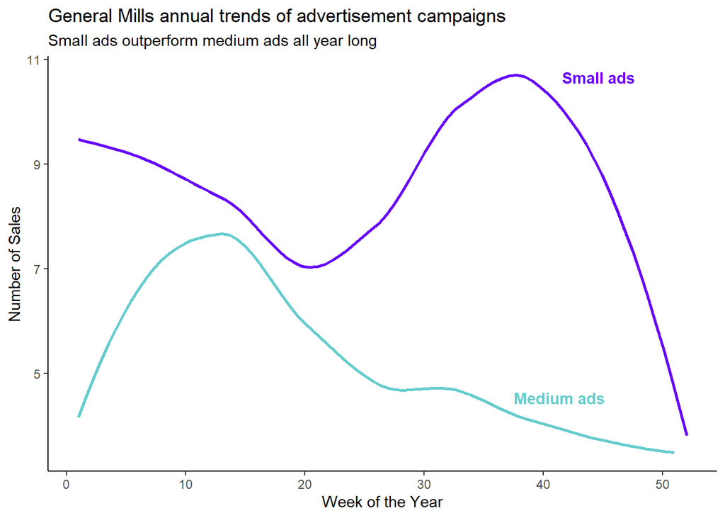

```r
cb_palette <- c("#6600FF", "#66CCCC")

# updates to line graph for memo
weekly_ad_sales_smooth <- cereal_numeric %>%
  mutate(ad = as.factor(ad)) %>%
  filter(company == 'General Mills') %>%
  filter(ad != "NONE") %>%
  group_by(week, ad) %>%
  summarise(count_n = n()) %>%
  ggplot(mapping = aes(x = week, y = count_n, color = ad, legend = "none")) +
  scale_color_manual(values = cb_palette) +
  geom_smooth(se = FALSE) +
  guides(color = "none", labels = "none") +
  theme_classic() +
  labs(x = "Week of the Year",
       y = "Number of Sales",
       title = "General Mills annual trends of advertisement campaigns",
       subtitle = "Small ads outperform medium ads all year long") +

  geom_text(data = data.frame(x = 39.0202225326685, y = 4.6481581052289, label = "Medium ads"),
            mapping = aes(x = x, y = y, label = label),
            hjust = 0.2, vjust = 1L, colour = "#66CCCC",  fontface = 2, inherit.aes = FALSE) +

  geom_text(data = data.frame(x = 43.1127335651892, y = 10.6604358222577, label = "Small ads"),
            mapping = aes(x = x, y = y, label = label),
            hjust = 0.25,colour = "#6600FF", fontface = 2, inherit.aes = FALSE)
# view the viz
weekly_ad_sales_smooth
```

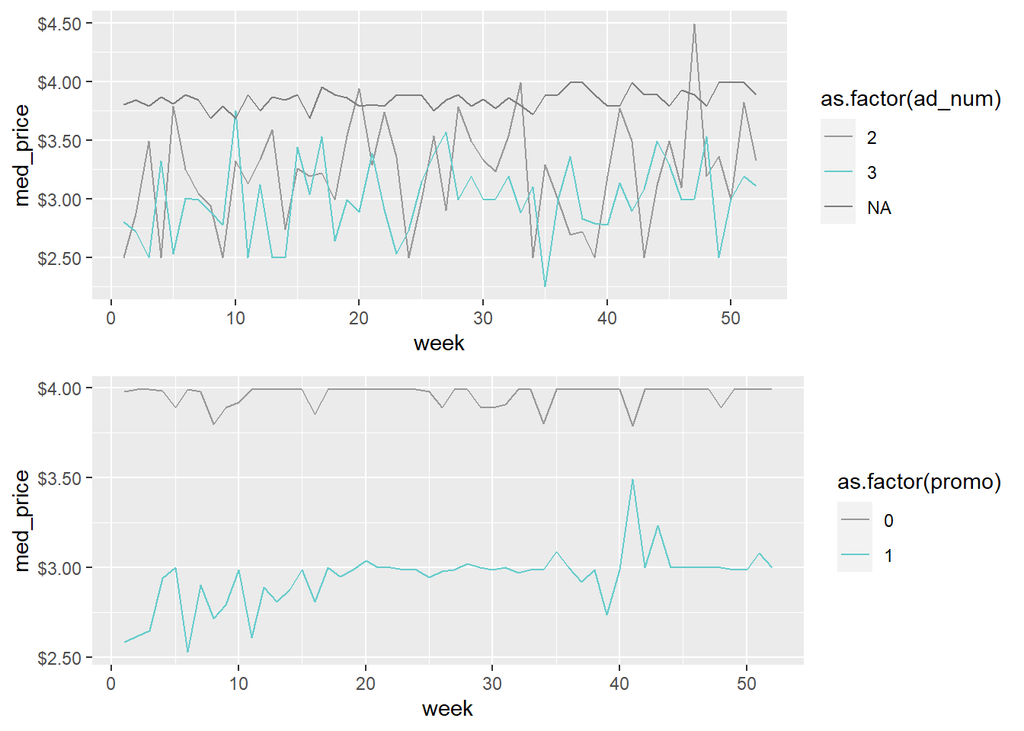

```r
# annotate the viz
#ggannotate(weekly_ad_sales)

# save the viz
ggsave(filename = "weekly_ad_sales_smooth.png", plot = weekly_ad_sales_smooth)
cereal_numeric <- cereal_ps %>%
  mutate(ad_num = case_when(
    str_starts(ad, 'none') ~ 1,
    str_starts(ad, 'A') ~ 2,
    str_starts(ad, 'B') ~ 3))

cb_palette <- c("#999999", "#66CCCC", "#6600FF")

promo_weekly_mp <- cereal_numeric %>%
  group_by(week, promo) %>%
  summarise(count_n = n(), med_price = median(price)) %>%
  ggplot(mapping = aes(x = week, y = med_price, color = as.factor(promo), legend = "none")) +
  scale_color_manual(values = cb_palette) +
  scale_y_continuous(labels = scales :: dollar) +
  geom_line()
ad_weekly_mp <- cereal_numeric %>%
  group_by(week, ad_num) %>%
  summarise(count_n = n(), med_price = median(price)) %>%
  ggplot(mapping = aes(x = week, y = med_price, color = as.factor(ad_num), legend = "none")) +
  scale_color_manual(values = cb_palette) +
  scale_y_continuous(labels = scales :: dollar) +
  geom_line()
grid.arrange(
ad_weekly_mp,

promo_weekly_mp,
ncol = 1)
```

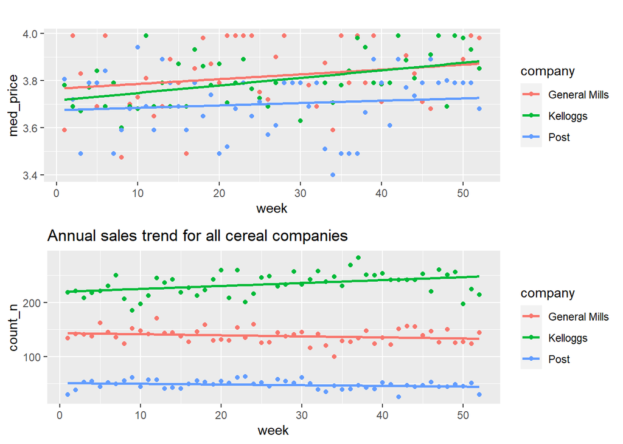

```r
grid.arrange(
  cereal_ps %>%
    group_by(week, company) %>%
    summarise(med_price = median(price)) %>%
    ggplot(mapping = aes(x = week, y = med_price, color = company)) +
    geom_point() +
    labs(title = "") +
    geom_smooth(method = "lm", se = FALSE),

  cereal_ps %>%
    group_by(week, company) %>%
    summarise(count_n = n()) %>%
    ggplot(mapping = aes(x = week, y = count_n, color = company)) +
    geom_point() +
    labs(title = "Annual sales trend for all cereal companies") +
    geom_smooth(method = "lm", se = FALSE)

)
```

**Comments**

```
- GM and Kelloggs median price unifies towards the end of the year (after week 30)
- Kelloggs has higher sales than GM all year
    - GM does not seem like a threat to Kelloggs at all
- GM sales of units seemed to decline overtime, whereas kelloggs grew. Why is that?
```

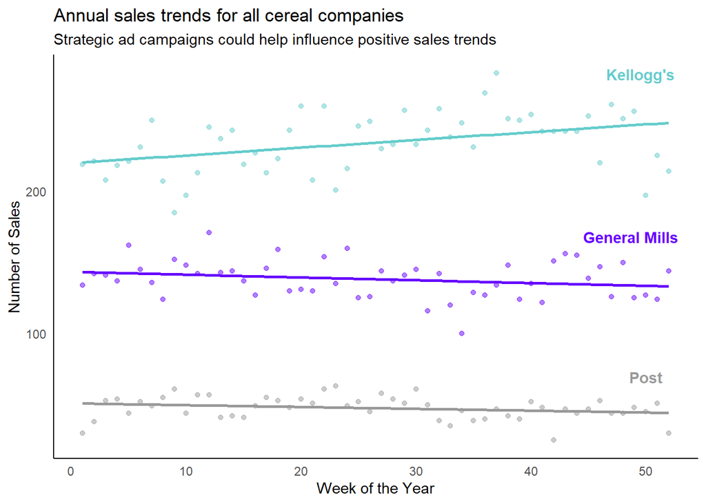

```r
# touch up scatter plot and save for memo

cb_palette <- c("#6600FF", "#66CCCC", "#999999")

company_sales_scatter <- cereal_ps %>%
  group_by(week, company) %>%
  summarise(count_n = n()) %>%
  ggplot(mapping = aes(x = week, y = count_n, color = company)) +
  scale_color_manual(values = cb_palette) +
  geom_point(alpha = 0.5) +
  labs(x = "Week of the Year",
       y = "Number of Sales",
       title = "Annual sales trends for all cereal companies",
       subtitle = "Strategic ad campaigns could help influence positive sales trends") +
  guides(color = "none", labels = "none") +
  theme_classic() +
  theme(axis.ticks.x = element_blank()) +
  theme(axis.ticks.y = element_blank()) +
  geom_smooth(method = "lm", se = FALSE) +

  geom_text(data = data.frame(x = 48.5822707072111, y = 69.4390740593849, label = "Post"),
            mapping = aes(x = x, y = y, label = label),
            hjust = 0L, colour = "#999999", fontface = 2, inherit.aes = FALSE) +

  geom_text(data = data.frame(x = c(47.7472046672058, 46.1814558421958 ),
                              y = c(282.469108673468, 167.977195797176),
                              label = c("Kellogg's", "General Mills")),
            mapping = aes(x = x, y = y, label = label),
            hjust = 0.2, colour = c("#66CCCC", "#6600FF"), fontface = 2, inherit.aes = FALSE)
# view the viz
company_sales_scatter
```

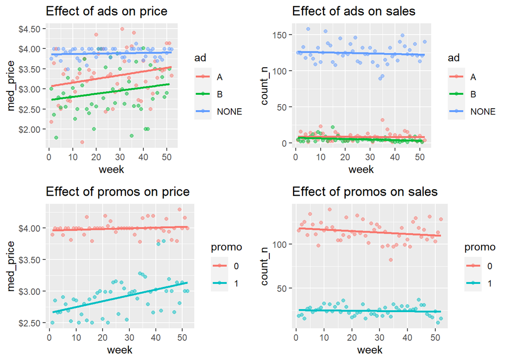

```r
# make annotations
# ggannotate(company_sales_scatter)

# save the viz
ggsave(filename = "company_sales_scatter.png", plot = company_sales_scatter)
# Focus on GM only
grid.arrange(
  # effects of ads on price
  cereal_ps %>%
    filter(company == "General Mills") %>%
    group_by(week, company, ad) %>%
    summarise(med_price = median(price)) %>%
    ggplot(mapping = aes(x = week, y = med_price, color = ad)) +
    geom_point(alpha = 0.5) +
    labs(title = "Effect of ads on price") +
    geom_smooth(method = "lm", se = FALSE) +
    scale_y_continuous(labels = dollar),

  # effects of ads on sales
  cereal_ps %>%
    filter(company == "General Mills") %>%
    group_by(week, company, ad) %>%
    summarise(count_n = n()) %>%
    ggplot(mapping = aes(x = week, y = count_n, color = ad)) +
    geom_point(alpha = 0.5) +
    labs(title = "Effect of ads on sales") +
    geom_smooth(method = "lm", se = FALSE),

  cereal_ps %>%
  # effects of promo on price
    filter(company == "General Mills") %>%
    group_by(week, company, promo) %>%
    mutate(promo = as.factor(promo)) %>%
    summarise(med_price = median(price)) %>%
    ggplot(mapping = aes(x = week, y = med_price, color = promo)) +
    geom_point(alpha = 0.5) +
    labs(title = "Effect of promos on price") +
    geom_smooth(method = "lm", se = FALSE) +
    scale_y_continuous(labels = dollar),

  # effects of promos on sales
  cereal_ps %>%
    filter(company == "General Mills") %>%
    mutate(promo = as.factor(promo)) %>%
    group_by(week, company, promo) %>%
    summarise(count_n = n()) %>%
    ggplot(mapping = aes(x = week, y = count_n, color = promo)) +
    geom_point(alpha = 0.5) +
    labs(title = "Effect of promos on sales") +
    geom_smooth(method = "lm", se = FALSE),

  ncol = 2
)
```

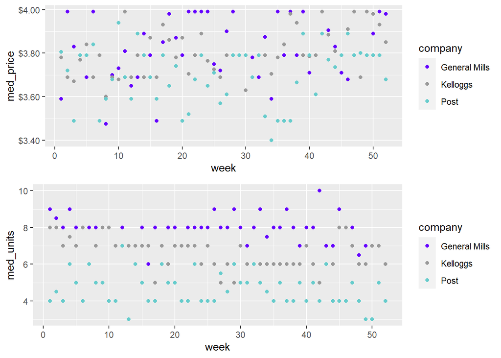

```r
cb_palette <- c("#6600FF", "#999999", "#66CCCC")

scatter_price <- cereal_ps %>%
  group_by(week, company) %>%
  summarise(med_price = median(price)) %>%
  ggplot(mapping = aes(y = med_price, x = week, color = company)) +
  scale_color_manual(values = cb_palette) +
  geom_point() + scale_y_continuous(labels = scales :: dollar)
scatter_units <- cereal_numeric %>%
  group_by(week, company) %>%
  summarise(med_units = median(units)) %>%
  ggplot(mapping = aes(y = med_units, x = week, color = company)) +
  geom_point() +
  scale_color_manual(values = cb_palette)
# view the plots
grid.arrange(

scatter_price,

scatter_units,

ncol = 1)
```

## 7.1 Deep Dive 1:

- Which brand from GM sold best at which store during promotion? (could do the same thing for advert B or A)

[figure not shown]

```r
cb_palette <- c("#33CCFF", "#999999", "#660099", "#CC3399")

top_stores <- cereal_ps %>%
  filter(company == 'General Mills') %>%
  filter(promo == '1') %>%
  group_by(iri_key, brand) %>%
  summarise(med_units = median(units)) %>%
  ungroup() %>%
  arrange(-med_units) %>%
  slice(1:5) %>% #Derived table from here

  ggplot() +
  geom_col(mapping = aes(x = iri_key, y = med_units, fill = brand)) +
  theme_classic() +
  scale_fill_manual(values = cb_palette) +
  labs(title = "Top 5 Stores For Promotions",
       subtitle = "In these stores there is also the best highlighted brand of cereal to sell during the promotion",
       fill = "Cereal Brand",
       y = "Summed Units Sold",
       x = "Store Number") +
  coord_flip() +

  geom_text(data = data.frame(x = c(240910.357235577, 241678.752707473, 244086.39185275),
                              y = c(23.6560426647789, 23.6560426647789, 23.6560426647789 ),
                              label = c("Store 240824", "Store 233072", "Store 230514 ")),
            mapping = aes(x = x, y = y, label = label),
            hjust = 0.55, colour = "white", inherit.aes = FALSE) +

  geom_text(data = data.frame(x = 233072.72342223, y = 23.6560426647789, label = "Store 241553"),
            mapping = aes(x = x, y = y, label = label),
            hjust = 0.55, vjust = 0.35, colour = "white", inherit.aes = FALSE) +

  geom_text(data = data.frame(x = 234609.514366023, y = 20.9131311236538, label = "Each of the top 5 stores sold 28 units \nduring the promotion"),
            mapping = aes(x = x, y = y, label = label),
            inherit.aes = FALSE) +

  geom_text(data = data.frame(x = 230511.405182574, y = 23.6560426647789, label = "Store 243941"),
            mapping = aes(x = x, y = y, label = label),
            hjust = 0.55, vjust = 0.35, colour = "white", inherit.aes = FALSE)
# view the viz
top_stores
```

```r
# make annotations
#ggannotate(top_stores)

# save the viz
ggsave(filename = "Best_Promo_Stores.png", plot = top_stores)
# make this bar chart a table and save it
top_stores <- cereal_ps %>%
  filter(company == 'General Mills') %>%
  filter(promo == '1') %>%
  group_by(iri_key, brand) %>%
  summarise(med_units = median(units)) %>%
  ungroup() %>%
  arrange(-med_units) %>%
  slice(1:5)%>%
  kable(align = 'l', booktabs = TRUE,
        caption = "Top brands of cereal sold at the top 5 stores",
        col.names = c("Store Number", "Best Brand", "Median Units Sold")) %>%
  kable_styling(full_width = F,
                latex_options = "scale_down",
                bootstrap_options = "striped")
top_stores
```

Top brands of cereal sold at the top 5 stores

| Store Number | Best Brand | Median Units Sold |
| --- | --- | --- |
| 230514 | Lucky Charms | 28 |
| 233072 | Cinnamon Toast Crunch | 28 |
| 240824 | Lucky Charms | 28 |
| 241553 | Cinnamon Toast Crunch | 28 |
| 243941 | Cocoa Puffs | 28 |

**Comments**

[output not shown]

[figure not shown]

```r
ggplot() +
  geom_col(data = cereal_ps, mapping = aes(x = iri_key, y = units, fill = brand))
```

## 7.2 Deep Dive 2:

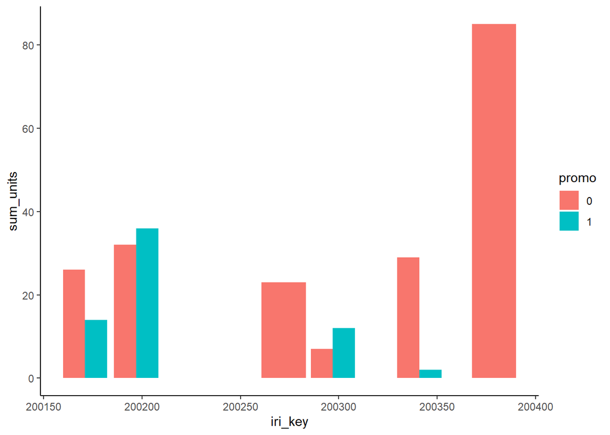

```r
cereal_ps %>%
  filter(company == 'General Mills') %>%
  mutate(promo = as.factor(promo)) %>%
  group_by(iri_key, promo) %>%
  summarise(sum_units = sum(units)) %>%
  #arrange(-sum_units) %>%
  ungroup() %>%
  slice(1:10) %>%

  ggplot(mapping = aes(x = iri_key, y = sum_units, fill = promo)) +
  geom_col(position = "dodge") +
  theme_classic() +
  scale_x_continuous(n.breaks = 5)
```

**Comments**

```
- It is not consistent that stores using promotions sell more promoted products than not promoted
- Interesting that stores without promotions still sell a lot of products in general
```

**Questions**

```
- It would be really important to look statistically at how often promotions out sell unmpromoted items
- Are pormotions cost effective?
```

## 7.3 Deep Dive 3:

- Which stores sell the most of the top brands under campaign A?

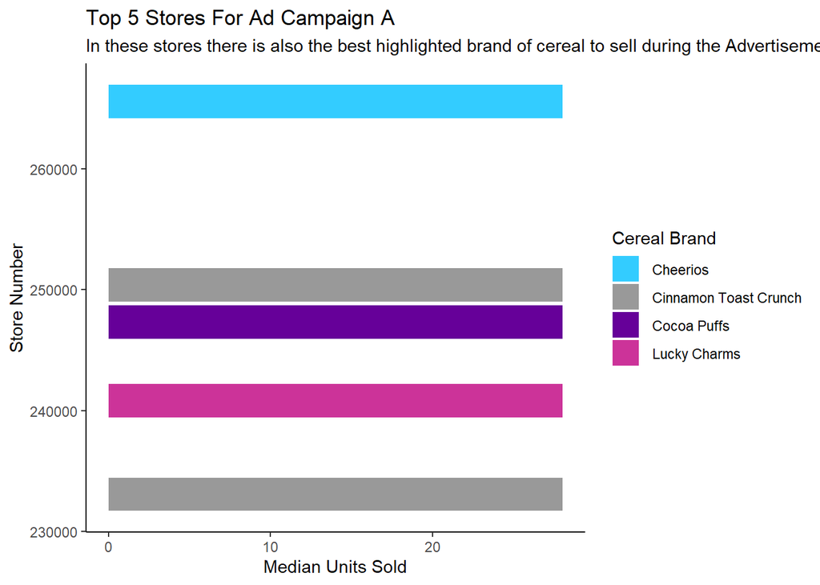

```r
## Deep Dive 3:
cb_palette <- c("#33CCFF", "#999999", "#660099", "#CC3399")

cereal_ps %>%
  filter(company == 'General Mills') %>%
  filter(ad == 'A') %>%
  group_by(iri_key, brand) %>%
  summarise(med_units = median(units)) %>%
  ungroup() %>%
  arrange(-med_units) %>%
  slice(1:5) %>%

  ggplot() +
  geom_col(mapping = aes(x = iri_key, y = med_units, fill = brand)) +
  theme_classic() +
  scale_fill_manual(values = cb_palette) +
  labs(title = "Top 5 Stores For Ad Campaign A",
       subtitle = "In these stores there is also the best highlighted brand of cereal to sell during the Advertisement",
       fill = "Cereal Brand",
       y = "Median Units Sold",
       x = "Store Number") +
  coord_flip()
```

**Comments**

```
- Again the set amount of max median units sold is 28, just like with the promotion.
- It is interesting the cinnammon toast crunch, lucky charms and cocoa puffs are still here as top sellers, just like
 in the promo
```

**Questions**

```
- It is very important to check the statistical differences in the sales rates of A and B, because it is easy
to look at the top selling stores and say that they are similar.
```

## 7.4 Deep Dive 4:

- Which stores sell the most of the top brands under campaign B?

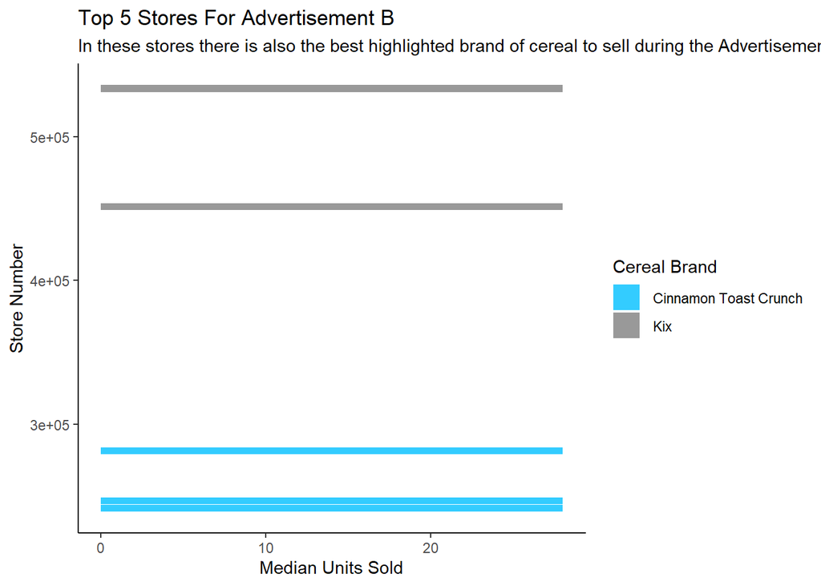

```r
cb_palette <- c("#33CCFF", "#999999", "#660099", "#CC3399")

cereal_ps %>%
  filter(company == 'General Mills') %>%
  filter(ad == 'B') %>%
  group_by(iri_key, brand) %>%
  summarise(med_units = median(units)) %>%
  ungroup() %>%
  arrange(-med_units) %>%
  slice(1:5) %>%

  ggplot() +
  geom_col(mapping = aes(x = iri_key, y = med_units, fill = brand)) +
  theme_classic() +
  scale_fill_manual(values = cb_palette) +
  labs(title = "Top 5 Stores For Advertisement B",
       subtitle = "In these stores there is also the best highlighted brand of cereal to sell during the Advertisement",
       fill = "Cereal Brand",
       y = "Median Units Sold",
       x = "Store Number") +
  coord_flip()
```

**comments**

[output not shown]

**Questions**

```
- So which campaign is actually selling more units, and what is most cost effective?
```

# 8 Statistical EDA

## 8.1 Univariate Regression

```r
#chisq.test(cereal_ps$price, cereal_ps$ad)

#chisq.test(cereal_ps$units, cereal_ps$ad)

#chisq.test(cereal_ps$price, cereal_ps$promo)

#chisq.test(cereal_ps$units, cereal_ps$promo)

#?chisq.test
price_ad <- lm(formula = price ~ ad, data = cereal_ps)

summary(price_ad)
```

```
##
## Call:
## lm(formula = price ~ ad, data = cereal_ps)
##
## Residuals:
##     Min      1Q  Median      3Q     Max
## -3.5827 -0.5660 -0.0227  0.6173  6.1573
##
## Coefficients:
##             Estimate Std. Error t value Pr(>|t|)
## (Intercept)  3.28733    0.02564 128.219  < 2e-16 ***
## adB         -0.13136    0.03949  -3.327 0.000881 ***
## adNONE       0.54534    0.02659  20.512  < 2e-16 ***
## ---
## Signif. codes:  0 '***' 0.001 '**' 0.01 '*' 0.05 '.' 0.1 ' ' 1
##
## Residual standard error: 0.9783 on 21847 degrees of freedom
## Multiple R-squared:  0.03748,    Adjusted R-squared:  0.03739
## F-statistic: 425.4 on 2 and 21847 DF,  p-value: < 2.2e-16
```

```r
export_summs(price_ad)
```

|  | Model 1 |
| --- | --- |
| (Intercept) | 3.29 *** |
|  | (0.03) |
| adB | -0.13 *** |
|  | (0.04) |
| adNONE | 0.55 *** |
|  | (0.03) |
| N | 21850 |
| R2 | 0.04 |
| *** p < 0.001; ** p < 0.01; * p < 0.05. |  |

**Comments**

- Does ad impact price?
  - Ho: Running advertisements does not impact the price of the sold products

**Practical Significance**

```
- On average, cereals under ad campaign B are priced 13 cents lower than ad campaign A
```

**Statistical Significance**

```
- Ads have a very consistent and large impact on price (large F-statistic of 425), with a p-value of less than .001
- The data is large, but is most likely only a small fraction of all total cereal bought throughout the year here in the US. There are millions of households all buying cereal, and we have a mere fraction of that.
```

**Technical sentence**

```
- We reject the null hypothesis that running ad campaigns does not impact the price of the sold products
```

**Non-technical sentence**

```
- Running ad campaigns impacts the price of cereal
```

```r
price_promo <- lm(formula = price ~ promo, data = cereal_ps)

summary(price_promo)
```

```
##
## Call:
## lm(formula = price ~ promo, data = cereal_ps)
##
## Residuals:
##     Min      1Q  Median      3Q     Max
## -3.6418 -0.4818  0.0182  0.5182  6.0182
##
## Coefficients:
##              Estimate Std. Error t value Pr(>|t|)
## (Intercept)  3.971846   0.006921  573.87   <2e-16 ***
## promo       -1.001780   0.015175  -66.01   <2e-16 ***
## ---
## Signif. codes:  0 '***' 0.001 '**' 0.01 '*' 0.05 '.' 0.1 ' ' 1
##
## Residual standard error: 0.9105 on 21848 degrees of freedom
## Multiple R-squared:  0.1663, Adjusted R-squared:  0.1663
## F-statistic:  4358 on 1 and 21848 DF,  p-value: < 2.2e-16
```

```r
export_summs(price_promo)
```

|  | Model 1 |
| --- | --- |
| (Intercept) | 3.97 *** |
|  | (0.01) |
| promo | -1.00 *** |
|  | (0.02) |
| N | 21850 |
| R2 | 0.17 |
| *** p < 0.001; ** p < 0.01; * p < 0.05. |  |

**Comments**

- Does promotion impact price
  - Ho: Running a promotion does not impact the price of the product

**Practical Significance**

```
- On average, cereals that are being promoted are priced 1 dollar lower than cereals that are not being promoted
```

**Statistical Significance**

```
- Promotions have a very consistent and large impact on price (large F-statistic of 4358), with a p-value of less than .001
- The data is large, but is most likely only a small fraction of all total cereal bought throughout the year here in the US. There are millions of households all buying cereal, and we have a mere fraction of that.
```

**Technical sentence**

```
- We reject the null hypothesis that running promotions does not impact the price of the sold products
```

**Non-technical sentence**

```
- Running promotions impacts the price of cereal
```

```r
units_ad <- lm(formula = units ~ ad, data = cereal_ps)

summary(units_ad)
```

```
##
## Call:
## lm(formula = units ~ ad, data = cereal_ps)
##
## Residuals:
##     Min      1Q  Median      3Q     Max
## -10.269  -5.270  -2.269   3.730  19.730
##
## Coefficients:
##             Estimate Std. Error t value Pr(>|t|)
## (Intercept)  10.7177     0.1742  61.527   <2e-16 ***
## adB           0.5509     0.2683   2.053   0.0401 *
## adNONE       -2.4475     0.1806 -13.549   <2e-16 ***
## ---
## Signif. codes:  0 '***' 0.001 '**' 0.01 '*' 0.05 '.' 0.1 ' ' 1
##
## Residual standard error: 6.647 on 21847 degrees of freedom
## Multiple R-squared:  0.01648,    Adjusted R-squared:  0.01639
## F-statistic: 183.1 on 2 and 21847 DF,  p-value: < 2.2e-16
```

```r
export_summs(units_ad)
```

|  | Model 1 |
| --- | --- |
| (Intercept) | 10.72 *** |
|  | (0.17) |
| adB | 0.55 * |
|  | (0.27) |
| adNONE | -2.45 *** |
|  | (0.18) |
| N | 21850 |
| R2 | 0.02 |
| *** p < 0.001; ** p < 0.01; * p < 0.05. |  |

**Comments**

- Does ad impact units sold?
  - Ho: Running an advertisement does not change the amount of units sold

**Practical Significance**

```
- On average, cereals under ad campaign B sell 0.55 units more than cereals under ad campaign A
```

**Statistical Significance**

[output not shown]

**Technical sentence**

```
- We reject the null hypothesis that running advertisements does not change the amount of units sold
```

**Non-technical sentence**

```
- Ad campaigns impact the units of cereal sold
```

```r
units_promo  <- lm(formula = units ~ promo, data = cereal_ps)

summary(units_promo)
```

```
##
## Call:
## lm(formula = units ~ promo, data = cereal_ps)
##
## Residuals:
##     Min      1Q  Median      3Q     Max
## -10.197  -4.891  -1.891   3.803  20.109
##
## Coefficients:
##             Estimate Std. Error t value Pr(>|t|)
## (Intercept)  7.89142    0.04992   158.1   <2e-16 ***
## promo        3.30528    0.10945    30.2   <2e-16 ***
## ---
## Signif. codes:  0 '***' 0.001 '**' 0.01 '*' 0.05 '.' 0.1 ' ' 1
##
## Residual standard error: 6.566 on 21848 degrees of freedom
## Multiple R-squared:  0.04007,    Adjusted R-squared:  0.04003
## F-statistic:   912 on 1 and 21848 DF,  p-value: < 2.2e-16
```

```r
export_summs(units_promo)
```

|  | Model 1 |
| --- | --- |
| (Intercept) | 7.89 *** |
|  | (0.05) |
| promo | 3.31 *** |
|  | (0.11) |
| N | 21850 |
| R2 | 0.04 |
| *** p < 0.001; ** p < 0.01; * p < 0.05. |  |

**Comments**

- Does promotion impact units sold?
  - Ho: Running a promotion does not impact the amount of units sold

**Practical Significance**

```
- On average, cereals that are being promoted sell 3.31 more units than cereals that are not being promoted
```

**Statistical Significance**

```
- Promotions have a consistent and large impact on units (large F-statistic of 912), with a p-value of less than .001
- The data is large, but is most likely only a small fraction of all total cereal bought throughout the year here in the US. There are millions of households all buying cereal, and we have a mere fraction of that.
```

**Technical sentence**

```
- We reject the null hypothesis that running promotions does not impact the amount of units sold
```

**Non-technical sentence**

```
- Cereal promotions impact the amount of units sold
```

## 8.2 Wilcox Test

- Advertisement and Promotions on Price

```r
wilcox.test(cereal_ps$price[cereal_ps$promo == 0], cereal_ps$price[cereal_ps$promo == 1], conf.int = TRUE) # running but not correct?
```

```
##
##  Wilcoxon rank sum test with continuity correction
##
## data:  cereal_ps$price[cereal_ps$promo == 0] and cereal_ps$price[cereal_ps$promo == 1]
## W = 64110893, p-value < 2.2e-16
## alternative hypothesis: true location shift is not equal to 0
## 95 percent confidence interval:
##  0.9900005 1.0299902
## sample estimates:
## difference in location
##               1.000007
```

```r
wilcox.test(cereal_ps$price[cereal_ps$ad == 'NONE'], cereal_ps$price[cereal_ps$ad == 'B'], conf.int = TRUE)
```

```
##
##  Wilcoxon rank sum test with continuity correction
##
## data:  cereal_ps$price[cereal_ps$ad == "NONE"] and cereal_ps$price[cereal_ps$ad == "B"]
## W = 14620939, p-value < 2.2e-16
## alternative hypothesis: true location shift is not equal to 0
## 95 percent confidence interval:
##  0.6899656 0.7999366
## sample estimates:
## difference in location
##              0.7399743
```

```r
wilcox.test(cereal_ps$price[cereal_ps$ad == 'NONE'], cereal_ps$price[cereal_ps$ad == 'A'], conf.int = TRUE)
```

```
##
##  Wilcoxon rank sum test with continuity correction
##
## data:  cereal_ps$price[cereal_ps$ad == "NONE"] and cereal_ps$price[cereal_ps$ad == "A"]
## W = 18704158, p-value < 2.2e-16
## alternative hypothesis: true location shift is not equal to 0
## 95 percent confidence interval:
##  0.5400374 0.6600537
## sample estimates:
## difference in location
##                0.60007
```

**Comments**

[output not shown]

- Advertisement and Promotions on Units sold

```r
wilcox.test(cereal_ps$units[cereal_ps$promo == 0], cereal_ps$units[cereal_ps$promo == 1], conf.int = TRUE)#running but not correct?
```

```
##
##  Wilcoxon rank sum test with continuity correction
##
## data:  cereal_ps$units[cereal_ps$promo == 0] and cereal_ps$units[cereal_ps$promo == 1]
## W = 28714242, p-value < 2.2e-16
## alternative hypothesis: true location shift is not equal to 0
## 95 percent confidence interval:
##  -3.000039 -2.999978
## sample estimates:
## difference in location
##              -2.999963
```

```r
wilcox.test(cereal_ps$units[cereal_ps$ad == 'NONE'], cereal_ps$units[cereal_ps$ad == 'B'], conf.int = TRUE)
```

```
##
##  Wilcoxon rank sum test with continuity correction
##
## data:  cereal_ps$units[cereal_ps$ad == "NONE"] and cereal_ps$units[cereal_ps$ad == "B"]
## W = 7903863, p-value < 2.2e-16
## alternative hypothesis: true location shift is not equal to 0
## 95 percent confidence interval:
##  -2.999979 -2.000010
## sample estimates:
## difference in location
##              -2.999992
```

```r
wilcox.test(cereal_ps$units[cereal_ps$ad == 'NONE'], cereal_ps$units[cereal_ps$ad == 'A'], conf.int = TRUE)
```

```
##
##  Wilcoxon rank sum test with continuity correction
##
## data:  cereal_ps$units[cereal_ps$ad == "NONE"] and cereal_ps$units[cereal_ps$ad == "A"]
## W = 11280327, p-value < 2.2e-16
## alternative hypothesis: true location shift is not equal to 0
## 95 percent confidence interval:
##  -2.000007 -1.999911
## sample estimates:
## difference in location
##              -2.000045
```

```r
#super rough will need to fix up to see if they are producing the right interpretations of what I want
```

**Comments**

[output not shown]

## 8.3 Median Test

```r
Median.test(cereal_ps$units, as.factor(cereal_ps$promo), alpha = 0.05)
```

```
##
## The Median Test for cereal_ps$units ~ as.factor(cereal_ps$promo)
##
## Chi Square = 573.3571   DF = 1   P.Value 1.044859e-126
## Median = 7
##
##   Median     r Min Max Q25 Q75
## 0      6 17305   1  28   3  11
## 1     10  4545   1  28   5  17
##
## Post Hoc Analysis
##
## Groups according to probability of treatment differences and alpha level.
##
## Treatments with the same letter are not significantly different.
##
##   cereal_ps$units groups
## 1              10      a
## 0               6      b
```

```r
Median.test(cereal_ps$units, as.factor(cereal_ps$ad), alpha = 0.05)
```

```
##
## The Median Test for cereal_ps$units ~ as.factor(cereal_ps$ad)
##
## Chi Square = 200.3728   DF = 2   P.Value 3.087432e-44
## Median = 7
##
##      Median     r Min Max Q25 Q75
## A         9  1456   1  28   4  16
## B        10  1061   1  28   5  17
## NONE      6 19333   1  28   3  12
##
## Post Hoc Analysis
##
## Groups according to probability of treatment differences and alpha level.
##
## Treatments with the same letter are not significantly different.
##
##      cereal_ps$units groups
## B                 10      a
## A                  9      a
## NONE               6      b
```

**Comments**

[output not shown]

```r
pairwise.t.test(cereal_ps$units, cereal_ps$ad, p.adjust.method = "bon")
```

```
##
##  Pairwise comparisons using t tests with pooled SD
##
## data:  cereal_ps$units and cereal_ps$ad
##
##      A      B
## B    0.12   -
## NONE <2e-16 <2e-16
##
## P value adjustment method: bonferroni
```

```r
pairwise.t.test(cereal_ps$units, cereal_ps$promo, p.adjust.method = "bon")
```

```
##
##  Pairwise comparisons using t tests with pooled SD
##
## data:  cereal_ps$units and cereal_ps$promo
##
##   0
## 1 <2e-16
##
## P value adjustment method: bonferroni
```

```r
pairwise.t.test(cereal_ps$price, cereal_ps$ad, p.adjust.method = "bon")
```

```
##
##  Pairwise comparisons using t tests with pooled SD
##
## data:  cereal_ps$price and cereal_ps$ad
##
##      A      B
## B    0.0026 -
## NONE <2e-16 <2e-16
##
## P value adjustment method: bonferroni
```

```r
pairwise.t.test(cereal_ps$price, cereal_ps$promo, p.adjust.method = "bon")
```

```
##
##  Pairwise comparisons using t tests with pooled SD
##
## data:  cereal_ps$price and cereal_ps$promo
##
##   0
## 1 <2e-16
##
## P value adjustment method: bonferroni
```

```r
#should we be comparing stores?
#compares if average ad value  is different across the units
```

## 8.4 More 1:1 Regression

```r
# regress units on store
reg_1 <- lm(units ~ iri_key, data = cereal_ps)

# view table
export_summs(reg_1)
```

|  | Model 1 |
| --- | --- |
| (Intercept) | 8.39 *** |
|  | (0.06) |
| iri_key | 0.00 *** |
|  | (0.00) |
| N | 21850 |
| R2 | 0.00 |
| *** p < 0.001; ** p < 0.01; * p < 0.05. |  |

```r
# regress units on ad and control for promo
reg_2 <- lm(units ~ factor(ad) + factor(promo), data = cereal_ps)

export_summs(reg_2)
```

|  | Model 1 |
| --- | --- |
| (Intercept) | 9.16 *** |
|  | (0.18) |
| factor(ad)B | 0.29 |
|  | (0.26) |
| factor(ad)NONE | -1.37 *** |
|  | (0.18) |
| factor(promo)1 | 2.93 *** |
|  | (0.12) |
| N | 21850 |
| R2 | 0.04 |
| *** p < 0.001; ** p < 0.01; * p < 0.05. |  |

```r
# run linear hypothesis with Ho: ad campaign B has no effect on units sold
linearHypothesis(reg_2, 'factor(ad)B = 0')
```

| Res.Df | RSS | Df | Sum of Sq | F | Pr(>F) |
| --- | --- | --- | --- | --- | --- |
| 2.18e+04 | 9.38e+05 |  |  |  |  |
| 2.18e+04 | 9.38e+05 | 1 | 50.5 | 1.18 | 0.278 |

```r
cereal_reg <- lm(formula = units ~ iri_key + price + volume + flavor + brand + company + week + promo + ad, data = cereal_ps)
cereal_sreg <- lm(formula = units ~ iri_key + price + volume + company + week + promo + ad, data = cereal_ps)

summary(cereal_reg)
```

```
##
## Call:
## lm(formula = units ~ iri_key + price + volume + flavor + brand +
##     company + week + promo + ad, data = cereal_ps)
##
## Residuals:
##     Min      1Q  Median      3Q     Max
## -16.625  -4.195  -1.268   3.216  24.739
##
## Coefficients: (5 not defined because of singularities)
##                               Estimate Std. Error t value Pr(>|t|)
## (Intercept)                  1.245e+01  2.929e-01  42.502  < 2e-16 ***
## iri_key                      4.532e-07  7.422e-08   6.106 1.04e-09 ***
## price                       -2.003e+00  6.239e-02 -32.102  < 2e-16 ***
## volume                       4.596e+00  1.813e-01  25.351  < 2e-16 ***
## flavorCocoa                 -1.043e+00  2.376e-01  -4.388 1.15e-05 ***
## flavorFruit                 -2.437e+00  1.938e-01 -12.578  < 2e-16 ***
## flavorRegular                1.373e+00  2.288e+00   0.600   0.5484
## flavorToasted                5.609e+00  2.143e-01  26.172  < 2e-16 ***
## brand Cinnamon Toast Crunch         NA         NA      NA       NA
## brand Cocoa Krispies        -2.228e+00  2.784e-01  -8.003 1.27e-15 ***
## brand Cocoa Puffs                   NA         NA      NA       NA
## brand Froot Loops                   NA         NA      NA       NA
## brand Frosted Flakes        -1.699e+00  2.287e+00  -0.743   0.4576
## brand Frosted Mini Wheats   -1.892e+00  2.288e+00  -0.827   0.4085
## brand Grape Nuts            -5.501e+00  2.290e+00  -2.402   0.0163 *
## brand Kix                   -1.869e+00  2.290e+00  -0.816   0.4145
## brand Lucky Charms          -4.528e+00  2.180e-01 -20.774  < 2e-16 ***
## brand Raisin Bran           -2.106e+00  2.290e+00  -0.920   0.3578
## brand Rice Krispies         -4.245e+00  2.240e-01 -18.949  < 2e-16 ***
## brand Shredded Wheat        -5.429e+00  2.290e+00  -2.371   0.0177 *
## brand Smart Start           -8.585e+00  2.412e-01 -35.599  < 2e-16 ***
## brand Special K             -4.593e+00  2.276e-01 -20.178  < 2e-16 ***
## companyKelloggs                     NA         NA      NA       NA
## companyPost                         NA         NA      NA       NA
## week                        -5.627e-03  2.754e-03  -2.043   0.0411 *
## promo                        1.577e+00  1.196e-01  13.184  < 2e-16 ***
## adB                          3.829e-01  2.438e-01   1.571   0.1163
## adNONE                      -9.366e-01  1.696e-01  -5.523 3.37e-08 ***
## ---
## Signif. codes:  0 '***' 0.001 '**' 0.01 '*' 0.05 '.' 0.1 ' ' 1
##
## Residual standard error: 6.032 on 21827 degrees of freedom
## Multiple R-squared:  0.1907, Adjusted R-squared:  0.1899
## F-statistic: 233.7 on 22 and 21827 DF,  p-value: < 2.2e-16
```

```r
summary(cereal_sreg)
```

```
##
## Call:
## lm(formula = units ~ iri_key + price + volume + company + week +
##     promo + ad, data = cereal_ps)
##
## Residuals:
##     Min      1Q  Median      3Q     Max
## -16.460  -4.546  -1.455   3.429  24.728
##
## Coefficients:
##                   Estimate Std. Error t value Pr(>|t|)
## (Intercept)      1.366e+01  2.689e-01  50.813  < 2e-16 ***
## iri_key          4.337e-07  7.727e-08   5.612 2.02e-08 ***
## price           -2.009e+00  5.927e-02 -33.892  < 2e-16 ***
## volume           4.645e+00  1.514e-01  30.678  < 2e-16 ***
## companyKelloggs -2.031e+00  9.573e-02 -21.216  < 2e-16 ***
## companyPost     -5.259e+00  1.581e-01 -33.262  < 2e-16 ***
## week            -6.897e-03  2.866e-03  -2.407   0.0161 *
## promo            1.399e+00  1.221e-01  11.461  < 2e-16 ***
## adB              3.827e-01  2.539e-01   1.507   0.1318
## adNONE          -9.430e-01  1.763e-01  -5.348 8.98e-08 ***
## ---
## Signif. codes:  0 '***' 0.001 '**' 0.01 '*' 0.05 '.' 0.1 ' ' 1
##
## Residual standard error: 6.283 on 21840 degrees of freedom
## Multiple R-squared:  0.1214, Adjusted R-squared:  0.121
## F-statistic: 335.3 on 9 and 21840 DF,  p-value: < 2.2e-16
```

```r
#export_summs(cereal_reg)
#export_summs(cereal_sreg)
```

**Comments**

[output not shown]

# 9 Summary

1. Advertisement campaign A (small ad) is just as efficient, if not more efficient than the advertisement campaign B (medium ad)
   - Advice: don’t do medium ad campaigns. Stick with the smaller campaigns (verify this)
   - GM to focus effort on small sized ad campaigns to drive sales
     - GM is currently on a negative annual sales trend
     - Main competitor, Kellogg’s, has a positive sales trend
     - GM must make adjustments to positively influence sales and continuing competing in cereal market
2. Focus in on promotion store that does the best
   - Focus on store and what their promotion tactics are and see if it can be applied to other stores to increase unit sales for GM.
   - Current promotion strategies are ineffective
     - They decrease the prices between 5% - 25%
       - This requires the sale of more units to break even, and even more sales to make a profit